# Sampling to learn words: Adults and children sample words that reduce referential ambiguity

Analysis walkthrough for the paper

Zettersten, M., & Saffran, J. (accepted). Sampling to learn words: Adults and children sample words that reduce referential ambiguity. Developmental Science.

For more background information and the underlying data, visit the OSF repository for this report: [OSF site](https://osf.io/udmvh/?view_only=b9b8a986fd3a4235a073ec35d70a2266)

See crossact_codebook for information about individual columns.

## Reading in data and preliminary processing

```r
d <- read.csv(data_path)
```

## Exclusions

Overview over exclusions in each experiment.

```r
##exclusions
exclusions <-  d %>%
  group_by(subject,experiment_name) %>%
  summarize(Exclude=Exclude[1]) %>%
  ungroup()  %>%
  group_by(experiment_name) %>%
  summarize(N=n(),num_exclusions=sum(Exclude!="N"))
kable(exclusions)
```

| experiment_name | N | num_exclusions |
| --- | --- | --- |
| Experiment 1 | 31 | 3 |
| Experiment 2 | 40 | 2 |
| Experiment 3 | 58 | 2 |
| Experiment S1 | 62 | 0 |

```r
#remove excluded participants
d <- d %>%
  filter(Exclude=="N")
```

## Demographics

Overview over demographic characteristics of each sample.

```r
##demographics (exclusions filtered)
demographics <- d %>%
  filter(Exclude=="N") %>%
  group_by(subject,age_group,experiment_name) %>%
  summarize(Gender=Gender[1],Age=Age[1],L1_english=L1_english[1],languages_besides_english_yn=languages_besides_english_yn[1],L1=L1[1],L1percent=L1percent[1]) %>%
  ungroup() %>%
  group_by(age_group,experiment_name)  %>%
  summarize(
    N=n(),
    gender_f=sum(Gender=="female"),
    mean_age=round(mean(Age,na.rm=T),2),
    sd_age=round(sd(Age,na.rm=T),2),
    min_age=round(min(Age,na.rm=T),2),
    max_age=round(max(Age,na.rm=T),2),
    native_english=ifelse(is.na(sum(L1_english=="English")),sum(L1=="English",na.rm=T),sum(L1_english=="English",na.rm=T)),
    languages_besides_english=ifelse(age_group[1]=="adults",NA,sum(languages_besides_english_yn=="Yes",na.rm=T)),
    monolingual=ifelse(age_group[1]=="adults",NA,sum(L1percent>=90,na.rm=T))
  )
```

### Experiment 1

```r
demographics %>%
  filter(experiment_name=="Experiment 1") %>%
  kable()
```

| age_group | experiment_name | N | gender_f | mean_age | sd_age | min_age | max_age | native_english | languages_besides_english | monolingual |
| --- | --- | --- | --- | --- | --- | --- | --- | --- | --- | --- |
| adults | Experiment 1 | 28 | 8 | 31.39 | 7.25 | 19 | 48 | 28 | NA | NA |

### Experiment 2

#### Gender, Age, Native Language

```r
demographics %>%
  filter(experiment_name=="Experiment 2") %>%
  kable()
```

| age_group | experiment_name | N | gender_f | mean_age | sd_age | min_age | max_age | native_english | languages_besides_english | monolingual |
| --- | --- | --- | --- | --- | --- | --- | --- | --- | --- | --- |
| kids | Experiment 2 | 38 | 19 | 5.9 | 1.19 | 4.1 | 8.12 | 38 | 6 | 32 |

#### Ethnicity

```r
d %>%
  filter(Exclude=="N"&experiment_name=="Experiment 2") %>%
  group_by(subject) %>%
  summarize(hispanic=hispanic[1],ethnicity=ethnicity[1]) %>%
  ungroup() %>%
  group_by(hispanic,ethnicity) %>%
  summarize(count=n()) %>%
  kable()
```

| hispanic | ethnicity | count |
| --- | --- | --- |
| No | Asian | 1 |
| No | Asian,White | 2 |
| No | Black or African American,White | 1 |
| No | Other | 1 |
| No | White | 30 |
| Yes | Other | 1 |
| Yes | White | 1 |
| NA | White | 1 |

### Experiment 3

Note that we are currently missing some demographic information (ethnicity & language) for 6 of the 56 participants, due to experimenter error.

#### Gender, Age, Native Language

```r
demographics %>%
  filter(experiment_name=="Experiment 3") %>%
  kable()
```

| age_group | experiment_name | N | gender_f | mean_age | sd_age | min_age | max_age | native_english | languages_besides_english | monolingual |
| --- | --- | --- | --- | --- | --- | --- | --- | --- | --- | --- |
| kids | Experiment 3 | 56 | 33 | 5.53 | 1.18 | 3.29 | 7.88 | 50 | 17 | 38 |

#### Ethnicity

```r
d %>%
  filter(Exclude=="N"&experiment_name=="Experiment 3") %>%
  group_by(subject) %>%
  summarize(hispanic=hispanic[1],ethnicity=ethnicity[1]) %>%
  ungroup() %>%
  group_by(hispanic,ethnicity) %>%
  summarize(count=n()) %>%
  kable()
```

| hispanic | ethnicity | count |
| --- | --- | --- |
| No | Asian | 8 |
| No | Asian,Black or African American | 1 |
| No | Asian,White | 1 |
| No | Black or African American | 1 |
| No | Black or African American,White | 1 |
| No | Black or African American,White,Other | 1 |
| No | Other | 1 |
| No | White | 33 |
| Yes | Other | 1 |
| Yes | White | 1 |
| NA | White | 1 |
| NA | NA | 6 |

### Experiment S1

```r
demographics %>%
  filter(experiment_name=="Experiment S1") %>%
  kable()
```

| age_group | experiment_name | N | gender_f | mean_age | sd_age | min_age | max_age | native_english | languages_besides_english | monolingual |
| --- | --- | --- | --- | --- | --- | --- | --- | --- | --- | --- |
| adults | Experiment S1 | 62 | 27 | 19.13 | 1.01 | 18 | 22 | 56 | NA | NA |

## Summarizing data by participant

First, we summarize sampling and test behavior by participant and store these objects for later plotting and analysis.

### Sampling

```r
#Summarize sampling and test behavior by subject
#used in later analyses and plotting

#selections by subject
subj_selection <- d %>%
  filter(trialType=="selection") %>%
  group_by(experiment_name,ambiguity_condition,subject) %>%
  summarize(
    N=n(),
    prop_ambig_selection=sum(selectionType!="low")/N,
    num_ambig_selection=sum(selectionType!="low"))

subj_selection %>%
  arrange(experiment_name,ambiguity_condition,subject) %>%
  DT::datatable()
```

|  | experiment_name | ambiguity_condition | subject | N | prop_ambig_selection | num_ambig_selection |
| --- | --- | --- | --- | --- | --- | --- |
| 1 | Experiment 1 | ambiguous | p105551 | 4 | 1 | 4 |
| 2 | Experiment 1 | ambiguous | p108449 | 4 | 1 | 4 |
| 3 | Experiment 1 | ambiguous | p147453 | 4 | 0.5 | 2 |
| 4 | Experiment 1 | ambiguous | p20106 | 4 | 1 | 4 |
| 5 | Experiment 1 | ambiguous | p239446 | 4 | 0.75 | 3 |
| 6 | Experiment 1 | ambiguous | p383593 | 4 | 0.25 | 1 |
| 7 | Experiment 1 | ambiguous | p437560 | 4 | 0.5 | 2 |
| 8 | Experiment 1 | ambiguous | p453195 | 4 | 0.25 | 1 |
| 9 | Experiment 1 | ambiguous | p501751 | 4 | 0.75 | 3 |
| 10 | Experiment 1 | ambiguous | p513792 | 4 | 1 | 4 |

[output cut: 174 more lines]

### Overall Test

```r
#test performance by subject
subj_test <- d %>%
  filter(trialType=="test") %>%
  group_by(experiment_name,ambiguity_condition,subject) %>%
  summarize(
    N=n(),
    accuracy=mean(isRight,na.rm=T))
subj_test %>%
  arrange(experiment_name,ambiguity_condition,subject) %>%
  DT::datatable()
```

|  | experiment_name | ambiguity_condition | subject | N | accuracy |
| --- | --- | --- | --- | --- | --- |
| 1 | Experiment 1 | ambiguous | p105551 | 8 | 1 |
| 2 | Experiment 1 | ambiguous | p108449 | 8 | 1 |
| 3 | Experiment 1 | ambiguous | p147453 | 8 | 0.625 |
| 4 | Experiment 1 | ambiguous | p20106 | 8 | 1 |
| 5 | Experiment 1 | ambiguous | p239446 | 8 | 0.5 |
| 6 | Experiment 1 | ambiguous | p383593 | 8 | 0 |
| 7 | Experiment 1 | ambiguous | p437560 | 8 | 0 |
| 8 | Experiment 1 | ambiguous | p453195 | 8 | 0.625 |
| 9 | Experiment 1 | ambiguous | p501751 | 8 | 0.75 |
| 10 | Experiment 1 | ambiguous | p513792 | 8 | 0.875 |

[output cut: 174 more lines]

### Test By Item

```r
#test performance split by item type (ambiguous vs. non-ambiguous)
subj_test_item <- d %>%
  filter(trialType=="test") %>%
  group_by(experiment_name,ambiguity_condition,subject,targetType,targetIsAmbiguous,targetIsAmbiguousYN) %>%
  summarize(
    N=n(),
    accuracy=mean(isRight,na.rm=T))
subj_test_item %>%
  arrange(experiment_name,ambiguity_condition,subject) %>%
  DT::datatable()
```

|  | experiment_name | ambiguity_condition | subject | targetType | targetIsAmbiguous | targetIsAmbiguousYN | N | accuracy |
| --- | --- | --- | --- | --- | --- | --- | --- | --- |
| 1 | Experiment 1 | ambiguous | p105551 | high | 1 | yes | 4 | 1 |
| 2 | Experiment 1 | ambiguous | p105551 | low | 0 | no | 4 | 1 |
| 3 | Experiment 1 | ambiguous | p108449 | high | 1 | yes | 4 | 1 |
| 4 | Experiment 1 | ambiguous | p108449 | low | 0 | no | 4 | 1 |
| 5 | Experiment 1 | ambiguous | p147453 | high | 1 | yes | 4 | 0.75 |
| 6 | Experiment 1 | ambiguous | p147453 | low | 0 | no | 4 | 0.5 |
| 7 | Experiment 1 | ambiguous | p20106 | high | 1 | yes | 4 | 1 |
| 8 | Experiment 1 | ambiguous | p20106 | low | 0 | no | 4 | 1 |
| 9 | Experiment 1 | ambiguous | p239446 | high | 1 | yes | 4 | 0.75 |
| 10 | Experiment 1 | ambiguous | p239446 | low | 0 | no | 4 | 0.25 |

[output cut: 358 more lines]

## Experiment 1

### Sampling

Analysis of learners’ sampling preferences.

#### Plot

Plot is based on estimates from the logistic mixed-effects model

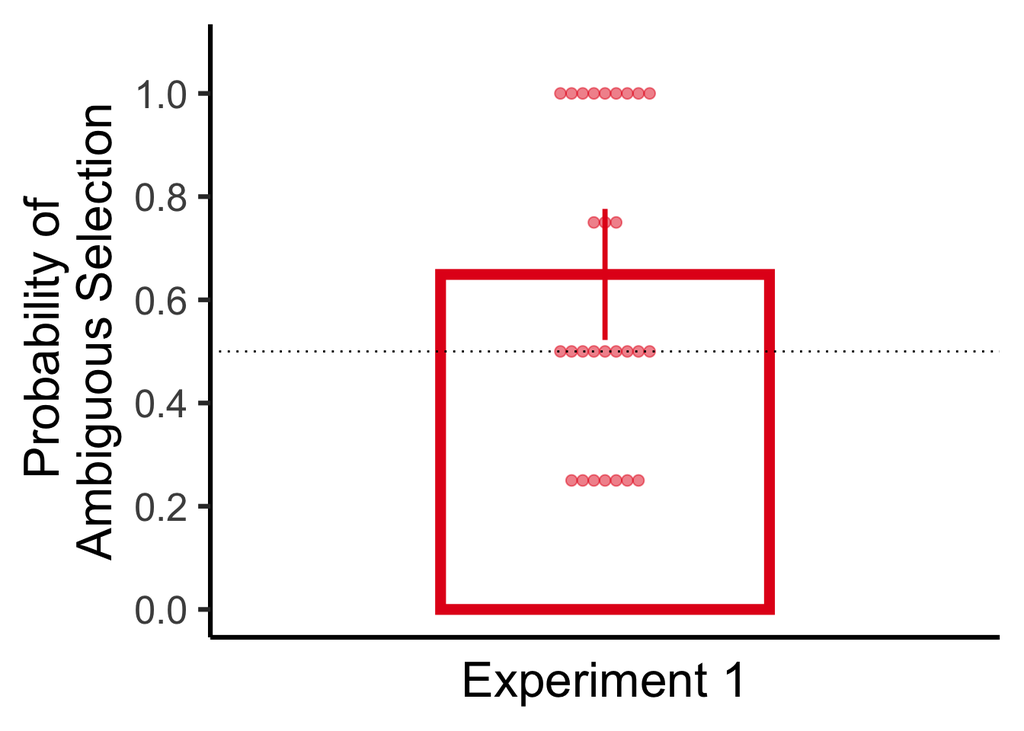

```r
#create data frame with model predictions
m <- glmer(isAmbiguous~(1|subject)+(1|choiceImage),data=subset(d,experiment_name=="Experiment 1"&trialType=="selection"&ambiguity_condition=="ambiguous"),family=binomial, glmerControl(optimizer="bobyqa",check.conv.singular="ignore"))
model_pred <- data.frame(ambiguity_condition="ambiguous")
pY <- predictSE(m,model_pred, type="response")
model_pred <- model_pred %>%
  mutate(
    experiment_name= "Experiment 1",
    prop_ambiguous = pY$fit,
    prop_ambiguous_lower_ci = pY$fit - 1.96*pY$se.fit,
    prop_ambiguous_upper_ci = pY$fit + 1.96*pY$se.fit)

#create plot
p_exp1_sampling <- ggplot(subset(model_pred,ambiguity_condition=="ambiguous"),aes(x=experiment_name,y=prop_ambiguous,color=ambiguity_condition,fill=ambiguity_condition))+
  geom_bar(stat="identity",size=2.5,fill="white",width=0.5)+
  geom_dotplot(data=subset(subj_selection,experiment_name=="Experiment 1"&ambiguity_condition=="ambiguous"), aes(y=prop_ambig_selection),binaxis="y",stackdir="center",alpha=0.5,dotsize=0.6)+
  geom_errorbar(aes(ymin=prop_ambiguous_lower_ci,ymax=prop_ambiguous_upper_ci),width=0,size=1.2)+
  ylab("Probability of \nAmbiguous Selection")+
  geom_hline(yintercept=0.5,linetype="dotted")+
  scale_y_continuous(breaks=c(0,0.2,0.4,0.6,0.8,1),limits=c(0,1.08))+
  scale_color_brewer(palette="Set1")+
  scale_fill_brewer(palette="Set1")+
  theme_classic(base_size=24)+
  theme(legend.position="none")+
  scale_x_discrete(name="Experiment 1")+
  theme(axis.ticks.x = element_blank(), axis.text.x = element_blank())
p_exp1_sampling
```

#### Descriptives

```r
#descriptives
subj_summary_1 <-  subj_selection %>%
  filter(experiment_name=="Experiment 1") %>%
  group_by(ambiguity_condition) %>%
  summarize(
    N=n(),
    prop_ambiguous=mean(prop_ambig_selection),
    ci_ambiguous=qt(0.975, N-1)*sd(prop_ambig_selection,na.rm=T)/sqrt(N),
    prop_ambiguous_lower_ci=prop_ambiguous-ci_ambiguous,
    prop_ambiguous_upper_ci=prop_ambiguous+ci_ambiguous,
  ) %>%
  select(-ci_ambiguous)
kable(subj_summary_1)
```

| ambiguity_condition | N | prop_ambiguous | prop_ambiguous_lower_ci | prop_ambiguous_upper_ci |
| --- | --- | --- | --- | --- |
| ambiguous | 28 | 0.625 | 0.5084928 | 0.7415072 |

#### Logistic mixed-effects model

```r
m <- glmer(isAmbiguous~(1|subject)+(1|choiceImage),data=subset(d,experiment_name=="Experiment 1"&trialType=="selection"&ambiguity_condition=="ambiguous"),family=binomial, glmerControl(optimizer="bobyqa",check.conv.singular="ignore"))
summary(m)
```

```
## Generalized linear mixed model fit by maximum likelihood (Laplace
##   Approximation) [glmerMod]
##  Family: binomial  ( logit )
## Formula: isAmbiguous ~ (1 | subject) + (1 | choiceImage)
##    Data:
## subset(d, experiment_name == "Experiment 1" & trialType == "selection" &
##     ambiguity_condition == "ambiguous")
## Control: glmerControl(optimizer = "bobyqa", check.conv.singular = "ignore")
##
##      AIC      BIC   logLik deviance df.resid
##    150.9    159.1    -72.5    144.9      109
##
## Scaled residuals:
##     Min      1Q  Median      3Q     Max
## -1.4998 -0.9396  0.5155  0.6668  1.0642
##
## Random effects:
##  Groups      Name        Variance Std.Dev.
##  subject     (Intercept) 0.845    0.9193
##  choiceImage (Intercept) 0.000    0.0000
## Number of obs: 112, groups:  subject, 28; choiceImage, 8
##
## Fixed effects:
##             Estimate Std. Error z value Pr(>|z|)
## (Intercept)   0.6155     0.2845   2.163   0.0305 *
## ---
## Signif. codes:  0 '***' 0.001 '**' 0.01 '*' 0.05 '.' 0.1 ' ' 1
```

```r
confint(m,method="Wald")[3,]
```

```
##      2.5 %     97.5 %
## 0.05777627 1.17315329
```

Note that we ignore a singular fit warning here. This appears to be caused by the inclusion of a by-item random intercept - however, it does not appear to adversely affect the model fit, and a simplified model with the by-stimulus random intercept removed yields virtually identical results.

#### Non-parametric test (Wilcoxon)

```r
wilcox.test(filter(subj_selection, experiment_name=="Experiment 1"&ambiguity_condition=="ambiguous")$prop_ambig_selection,mu=1/2, conf.int=T, conf.level=0.95)
```

```
##
##  Wilcoxon signed rank test with continuity correction
##
## data:  filter(subj_selection, experiment_name == "Experiment 1" & ambiguity_condition ==     "ambiguous")$prop_ambig_selection
## V = 151.5, p-value = 0.02026
## alternative hypothesis: true location is not equal to 0.5
## 95 percent confidence interval:
##  0.5000775 0.8750528
## sample estimates:
## (pseudo)median
##       0.625024
```

### Test

Analysis of learners’ test performance.

#### Plot

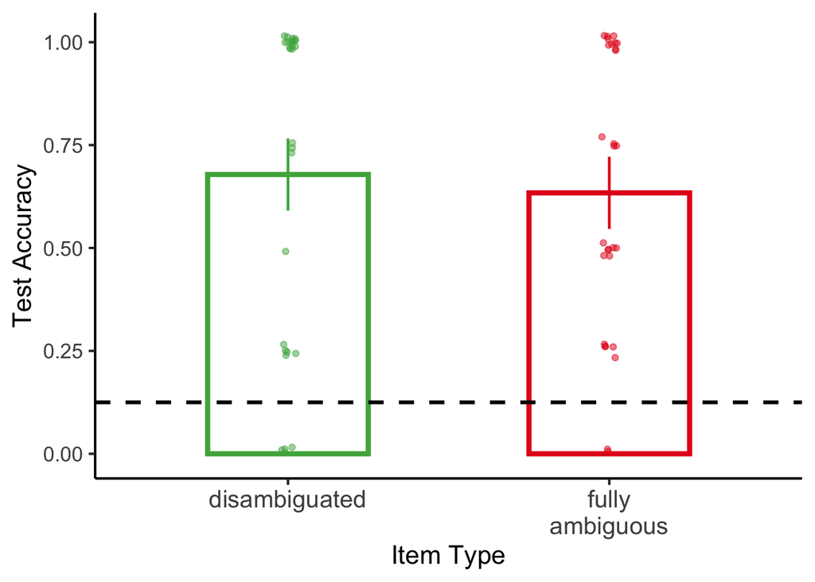

```r
## split by item, within-subjects corrected CIs
subj_summary_test_item_1 <-  summarySEwithin(
  filter(
    subj_test_item,
    experiment_name=="Experiment 1"),
  "accuracy",
  betweenvars=c("experiment_name","ambiguity_condition"),
  withinvars=c("targetIsAmbiguousYN"),
  idvar="subject") %>%
  mutate(
    lower_ci = accuracy - ci,
    upper_ci = accuracy + ci
  ) %>%
  select(-accuracy_norm,-sd,-se,-ci)
## by-item test plot
ggplot(subj_summary_test_item_1,aes(x=targetIsAmbiguousYN,y=accuracy,color=targetIsAmbiguousYN,fill=targetIsAmbiguousYN))+
  geom_bar(stat="identity",size=1.5,position=position_dodge(.53),width=0.5,alpha=0)+
  geom_point(data=filter(subj_test_item,experiment_name=="Experiment 1"),aes(fill=targetIsAmbiguousYN),alpha=0.5,position=position_jitterdodge(dodge.width=0.53,jitter.width=0.1,jitter.height=0.02))+
  geom_errorbar(aes(ymin=lower_ci,ymax=upper_ci),width=0.0,size=0.8,position=position_dodge(.53))+
  scale_color_manual(name="Item Type",
                     limits=c("no","yes"),
                     labels=c("disambiguated","ambiguous"),
                     values=c("#4DAF4A","#E41A1C"))+
  scale_fill_manual(name="Item Type",
                    limits=c("no","yes"),
                    labels=c("disambiguated","ambiguous"),
                    values=c("#4DAF4A","#E41A1C"))+
  scale_x_discrete(name = "Item Type",
                   limits=c("no","yes"),
                   labels=c("disambiguated","fully\nambiguous"))+
  ylab("Test Accuracy")+
  geom_hline(yintercept=1/8,linetype="dashed",size=1.1)+
  theme_classic(base_size=16)+
  theme(legend.position="none", axis.text.x=element_text(size=15))
```

#### Descriptives

##### Overall Test Accuracy

```r
## descriptives
subj_summary_test_1 <-  subj_test %>%
  filter(experiment_name=="Experiment 1") %>%
  group_by(experiment_name,ambiguity_condition) %>%
  summarize(
    N=n(),
    prop_correct=mean(accuracy,na.rm=T),
    ci=qt(0.975, N-1)*sd(accuracy,na.rm=T)/sqrt(N),
    prop_correct_lower_ci=prop_correct-ci,
    prop_correct_upper_ci=prop_correct+ci
  ) %>%
  select(-ci)
kable(subj_summary_test_1)
```

| experiment_name | ambiguity_condition | N | prop_correct | prop_correct_lower_ci | prop_correct_upper_ci |
| --- | --- | --- | --- | --- | --- |
| Experiment 1 | ambiguous | 28 | 0.65625 | 0.5265768 | 0.7859232 |

##### Test Accuracy Split by Item

```r
kable(subj_summary_test_item_1)
```

| experiment_name | ambiguity_condition | targetIsAmbiguousYN | N | accuracy | lower_ci | upper_ci |
| --- | --- | --- | --- | --- | --- | --- |
| Experiment 1 | ambiguous | no | 28 | 0.6785714 | 0.5909601 | 0.7661827 |
| Experiment 1 | ambiguous | yes | 28 | 0.6339286 | 0.5463173 | 0.7215399 |

#### Logistic mixed-effects model

##### Overall Test Accuracy

```r
## testing overall accuracy against chance
d$offset.125 <- 1/8
m <- glmer(isRight~offset(logit(offset.125))+(1|subject)+(1|targetImage),data=filter(d,experiment_name=="Experiment 1"&trialType=="test"),family=binomial,glmerControl(optimizer="bobyqa"))
summary(m)
```

```
## Generalized linear mixed model fit by maximum likelihood (Laplace
##   Approximation) [glmerMod]
##  Family: binomial  ( logit )
## Formula:
## isRight ~ offset(logit(offset.125)) + (1 | subject) + (1 | targetImage)
##    Data: filter(d, experiment_name == "Experiment 1" & trialType == "test")
## Control: glmerControl(optimizer = "bobyqa")
##
##      AIC      BIC   logLik deviance df.resid
##    236.0    246.3   -115.0    230.0      221
##
## Scaled residuals:
##     Min      1Q  Median      3Q     Max
## -2.1422 -0.4954  0.2084  0.5398  2.0369
##
## Random effects:
##  Groups      Name        Variance Std.Dev.
##  subject     (Intercept) 5.30551  2.3034
##  targetImage (Intercept) 0.09789  0.3129
## Number of obs: 224, groups:  subject, 28; targetImage, 8
##
## Fixed effects:
##             Estimate Std. Error z value Pr(>|z|)
## (Intercept)   3.1893     0.5097   6.258 3.91e-10 ***
## ---
## Signif. codes:  0 '***' 0.001 '**' 0.01 '*' 0.05 '.' 0.1 ' ' 1
```

##### Testing Difference between Items

```r
## testing difference between items
d$targetIsAmbiguousC <- ifelse(!is.na(d$targetIsAmbiguous) & d$targetIsAmbiguous==1,0.5,
                                        ifelse(!is.na(d$targetIsAmbiguous) & d$targetIsAmbiguous==0,-0.5,NA))
m <- glmer(isRight~1+targetIsAmbiguousC+(1+targetIsAmbiguousC|subject)+(1|targetImage),data=filter(d,(experiment_name=="Experiment 1")&trialType=="test"),family=binomial,glmerControl(optimizer="bobyqa"))
summary(m)
```

```
## Generalized linear mixed model fit by maximum likelihood (Laplace
##   Approximation) [glmerMod]
##  Family: binomial  ( logit )
## Formula: isRight ~ 1 + targetIsAmbiguousC + (1 + targetIsAmbiguousC |
##     subject) + (1 | targetImage)
##    Data: filter(d, (experiment_name == "Experiment 1") & trialType ==
##     "test")
## Control: glmerControl(optimizer = "bobyqa")
##
##      AIC      BIC   logLik deviance df.resid
##    233.5    253.9   -110.7    221.5      218
##
## Scaled residuals:
##     Min      1Q  Median      3Q     Max
## -2.0032 -0.4774  0.0571  0.3672  1.7067
##
## Random effects:
##  Groups      Name               Variance Std.Dev. Corr
##  subject     (Intercept)        9.14612  3.024
##              targetIsAmbiguousC 8.80532  2.967    -0.98
##  targetImage (Intercept)        0.01905  0.138
## Number of obs: 224, groups:  subject, 28; targetImage, 8
##
## Fixed effects:
##                    Estimate Std. Error z value Pr(>|z|)
## (Intercept)          1.6280     0.7177   2.268   0.0233 *
## targetIsAmbiguousC  -1.5652     0.9516  -1.645   0.1000
## ---
## Signif. codes:  0 '***' 0.001 '**' 0.01 '*' 0.05 '.' 0.1 ' ' 1
##
## Correlation of Fixed Effects:
##             (Intr)
## trgtIsAmbgC -0.823
```

```r
confint(m, method="Wald")[5:6,]
```

```
##                         2.5 %    97.5 %
## (Intercept)         0.2213282 3.0345876
## targetIsAmbiguousC -3.4303089 0.2999958
```

#### Relationship between sampling and test accuracy

```r
#join sampling and test
subj_selection <- subj_selection %>%
  left_join(subj_test,by=c("subject","experiment_name","ambiguity_condition"))

#correlation between preference for sampling ambiguous items and test performance
cor.test(subset(subj_selection,ambiguity_condition=="ambiguous"&experiment_name=="Experiment 1")$accuracy,subset(subj_selection,ambiguity_condition=="ambiguous"&experiment_name=="Experiment 1")$prop_ambig_selection)
```

```
##
##  Pearson's product-moment correlation
##
## data:  subset(subj_selection, ambiguity_condition == "ambiguous" & experiment_name ==  and subset(subj_selection, ambiguity_condition == "ambiguous" & experiment_name ==     "Experiment 1")$accuracy and     "Experiment 1")$prop_ambig_selection
## t = 3.6465, df = 26, p-value = 0.001167
## alternative hypothesis: true correlation is not equal to 0
## 95 percent confidence interval:
##  0.2664476 0.7845213
## sample estimates:
##       cor
## 0.5817003
```

Plot correlation between sampling preference and test accuracy

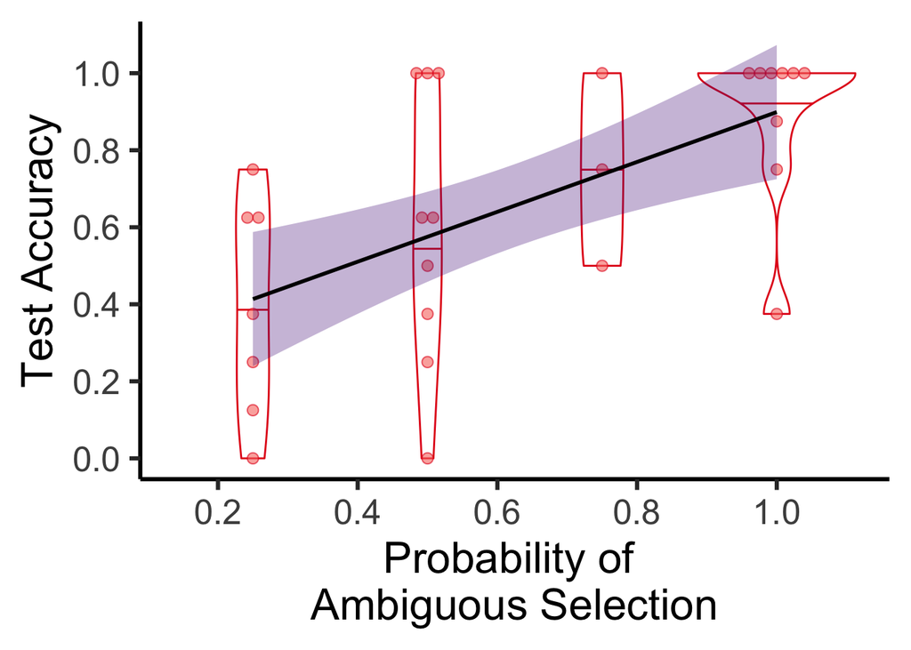

```r
p_exp1_sampling_test <- ggplot(filter(subj_selection,experiment_name=="Experiment 1"),aes(prop_ambig_selection,accuracy, color=ambiguity_condition))+
  geom_violin(aes(group=prop_ambig_selection),draw_quantiles=c(0.5))+
  geom_dotplot(aes(group=prop_ambig_selection,fill=ambiguity_condition),alpha=0.6,binaxis="y",stackdir="center",dotsize=0.8)+
  scale_color_manual(limits=c("ambiguous"),
                     values=c("#E41A1C"))+
  geom_smooth(method="lm",color="black",fill="#4B0082",alpha=0.3)+
  theme_classic()+
  scale_x_continuous(breaks=c(0,0.2,0.4,0.6,0.8,1))+
  scale_y_continuous(breaks=c(0,0.2,0.4,0.6,0.8,1),limits=c(0,1.08))+
  theme_classic(base_size=24)+
  ylab("Test Accuracy")+
  theme(legend.position="none")+
  xlab("Probability of \nAmbiguous Selection")
p_exp1_sampling_test
```

## Experiment 2

### Sampling

Analysis of learners’ sampling preferences.

#### Plot

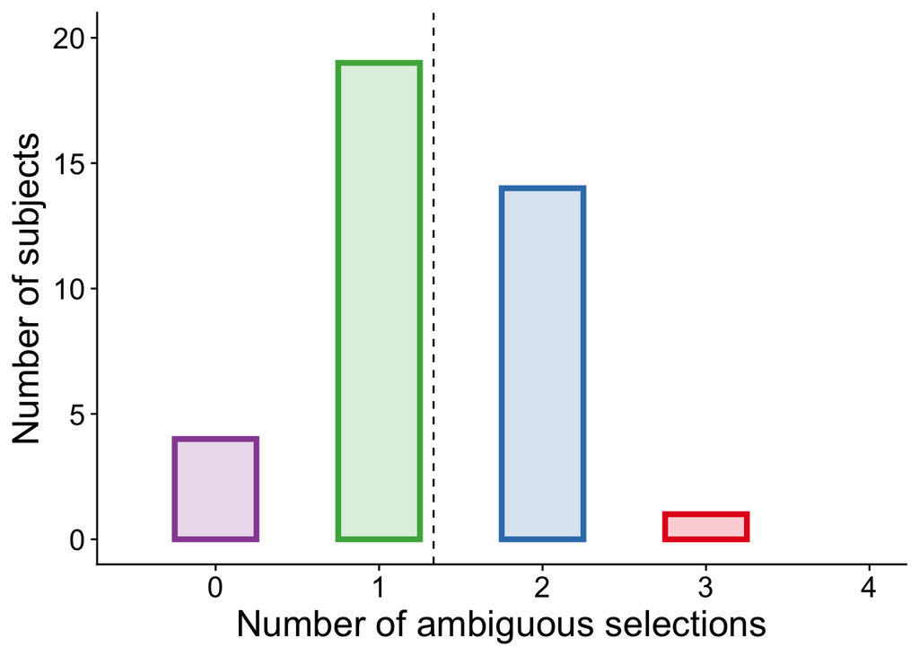

```r
ggplot(filter(subj_selection,experiment_name=="Experiment 2"),aes(x=num_ambig_selection,fill=as.factor(num_ambig_selection),color=as.factor(num_ambig_selection)))+
  scale_fill_brewer(palette="Set1",direction=-1)+
  scale_color_brewer(palette="Set1",direction=-1)+
  geom_bar(stat="count",size=1.5,alpha=0.2,width=0.5)+
  geom_vline(xintercept=4/3,linetype="dashed")+
  theme(axis.title = element_text(size=20),
        axis.text  = element_text(size=16),
        legend.position="none")+
  ylab("Number of subjects")+
  xlab("Number of ambiguous selections")+
  #geom_density(aes(group=1, y=..count../1.3))+
  scale_x_continuous(breaks=c(0,1,2,3,4), limits=c(-0.5,4))+
  scale_y_continuous(breaks=c(0,5,10,15,20,25,30), limits=c(0,20))
```

#### Descriptives

```r
#descriptives
subj_summary_2 <-  subj_selection %>%
  filter(experiment_name=="Experiment 2") %>%
  group_by(ambiguity_condition) %>%
  summarize(
    N=n(),
    prop_ambiguous=mean(prop_ambig_selection),
    ci_ambiguous=qt(0.975, N-1)*sd(prop_ambig_selection,na.rm=T)/sqrt(N),
    prop_ambiguous_lower_ci=prop_ambiguous-ci_ambiguous,
    prop_ambiguous_upper_ci=prop_ambiguous+ci_ambiguous,
  ) %>%
  select(-ci_ambiguous)
kable(subj_summary_2)
```

| ambiguity_condition | N | prop_ambiguous | prop_ambiguous_lower_ci | prop_ambiguous_upper_ci |
| --- | --- | --- | --- | --- |
| ambiguous | 38 | 0.3289474 | 0.2712987 | 0.386596 |

#### Logistic mixed-effects model

```r
d$offset.33 <- 1/3
m <- glmer(isAmbiguous~offset(logit(offset.33))+(1|subject)+(1|choiceImage),data=subset(d,experiment_name=="Experiment 2"&trialType=="selection"),family=binomial, glmerControl(optimizer="bobyqa",check.conv.singular="ignore"))
summary(m)
```

```
## Generalized linear mixed model fit by maximum likelihood (Laplace
##   Approximation) [glmerMod]
##  Family: binomial  ( logit )
## Formula: isAmbiguous ~ offset(logit(offset.33)) + (1 | subject) + (1 |
##     choiceImage)
##    Data:
## subset(d, experiment_name == "Experiment 2" & trialType == "selection")
## Control: glmerControl(optimizer = "bobyqa", check.conv.singular = "ignore")
##
##      AIC      BIC   logLik deviance df.resid
##    198.6    207.6    -96.3    192.6      149
##
## Scaled residuals:
##     Min      1Q  Median      3Q     Max
## -0.7001 -0.7001 -0.7001  1.4283  1.4283
##
## Random effects:
##  Groups      Name        Variance Std.Dev.
##  subject     (Intercept) 0        0
##  choiceImage (Intercept) 0        0
## Number of obs: 152, groups:  subject, 38; choiceImage, 6
##
## Fixed effects:
##             Estimate Std. Error z value Pr(>|z|)
## (Intercept)  -0.0198     0.1726  -0.115    0.909
```

```r
confint(m, method="Wald")[3,]
```

```
##      2.5 %     97.5 %
## -0.3581671  0.3185617
```

Note that we ignore a singular fit warning here. This appears to be caused by the inclusion of a by-item random intercept - however, it does not appear to adversely affect the model fit, and a simplified model with the by-stimulus random intercept removed yields virtually identical results.

#### Non-parametric test (Wilcoxon)

```r
wilcox.test(filter(subj_selection,experiment_name=="Experiment 2")$prop_ambig_selection,mu=1/3, conf.int=T, conf.level=0.95)
```

```
##
##  Wilcoxon signed rank test with continuity correction
##
## data:  filter(subj_selection, experiment_name == "Experiment 2")$prop_ambig_selection
## V = 409, p-value = 0.5734
## alternative hypothesis: true location is not equal to 0.3333333
## 95 percent confidence interval:
##  0.2500390 0.3750141
## sample estimates:
## (pseudo)median
##      0.3749301
```

#### Relationship with Age

```r
#predict ambiguous selections from age
m <- glmer(isAmbiguous~Age+(1|subject)+(1|choiceImage),data=subset(d,experiment_name=="Experiment 2"&trialType=="selection"),family=binomial,glmerControl(optimizer="bobyqa",check.conv.singular="ignore"))
summary(m)
```

```
## Generalized linear mixed model fit by maximum likelihood (Laplace
##   Approximation) [glmerMod]
##  Family: binomial  ( logit )
## Formula: isAmbiguous ~ Age + (1 | subject) + (1 | choiceImage)
##    Data:
## subset(d, experiment_name == "Experiment 2" & trialType == "selection")
## Control: glmerControl(optimizer = "bobyqa", check.conv.singular = "ignore")
##
##      AIC      BIC   logLik deviance df.resid
##    200.6    212.7    -96.3    192.6      148
##
## Scaled residuals:
##     Min      1Q  Median      3Q     Max
## -0.7034 -0.7006 -0.6989  1.4260  1.4334
##
## Random effects:
##  Groups      Name        Variance Std.Dev.
##  subject     (Intercept) 0        0
##  choiceImage (Intercept) 0        0
## Number of obs: 152, groups:  subject, 38; choiceImage, 6
##
## Fixed effects:
##              Estimate Std. Error z value Pr(>|z|)
## (Intercept) -0.737329   0.881389  -0.837    0.403
## Age          0.004131   0.146437   0.028    0.977
##
## Correlation of Fixed Effects:
##     (Intr)
## Age -0.981
```

```r
confint(m, method="Wald")[3:4,]
```

```
##                  2.5 %    97.5 %
## (Intercept) -2.4648196 0.9901613
## Age         -0.2828792 0.2911415
```

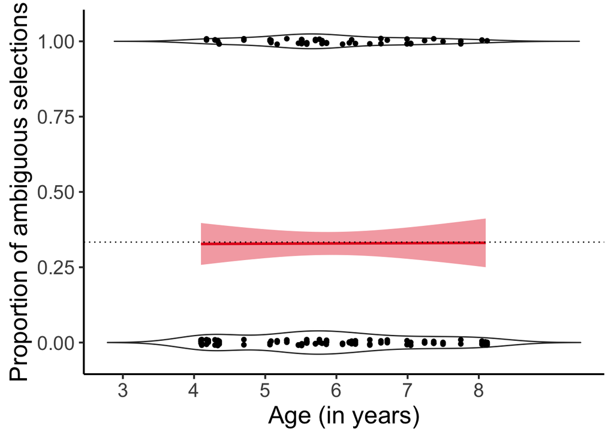

```r
#plot model predictions
pX <- data.frame(Age=seq(min(subset(d,experiment_name=="Experiment 2"&trialType=="selection")$Age,na.rm=T),max(subset(d,experiment_name=="Experiment 2"&trialType=="selection")$Age,na.rm=T),by=0.1))
pY <- predictSE(m,pX,re.form=NA,type="response")
pX$isAmbiguous <- pY$fit
pX$YLower <- pY$fit-pY$se.fit
pX$YUpper <- pY$fit+pY$se.fit
ggplot(pX,aes(Age,isAmbiguous))+
  geom_violinh(data=subset(d,experiment_name=="Experiment 2"&trialType=="selection"),aes(y=isAmbiguous,group=isAmbiguous),scale="count",width=0.1, trim=F)+
  geom_jitter(data=subset(d,experiment_name=="Experiment 2"&trialType=="selection"),aes(y=isAmbiguous,group=isAmbiguous),height=0.01)+
  geom_smooth(aes(ymin=YLower,ymax=YUpper),stat="identity",color="#E41A1C",fill="#E41A1C")+
  geom_hline(yintercept=1/3,linetype="dotted")+
  theme_classic(base_size=16)+
  xlab("Age (in years)")+
  scale_x_continuous(breaks=c(3,4,5,6,7,8))+
  ylab("Proportion of ambiguous selections")+
  theme(axis.title = element_text(size=20),
        axis.text  = element_text(size=16))
```

### Test

#### Plot

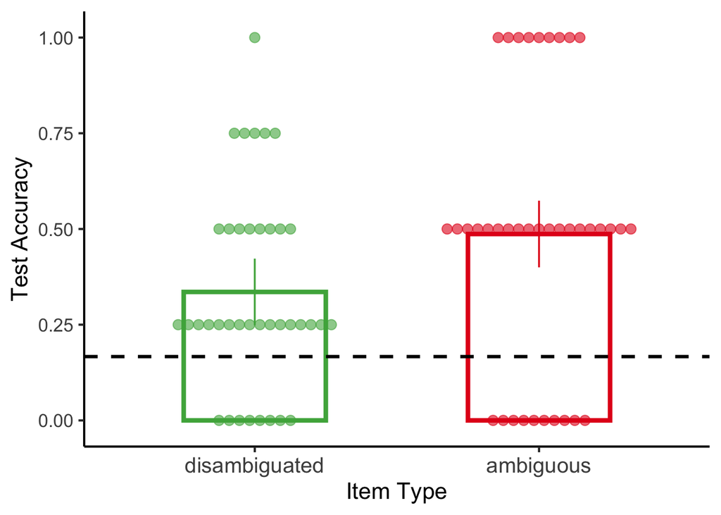

```r
#summarize across participants by item type
subj_summary_item_2 <- summarySEwithin(
  filter(
    subj_test_item,
    (experiment_name=="Experiment 2")),
  "accuracy",
  betweenvars=c("experiment_name","ambiguity_condition"),
  withinvars=c("targetIsAmbiguousYN"),
  idvar="subject") %>%
  mutate(
    lower_ci = accuracy - ci,
    upper_ci = accuracy + ci
  ) %>%
  select(-accuracy_norm,-sd,-se,-ci)
## create plot
ggplot(subj_summary_item_2,aes(x=targetIsAmbiguousYN,y=accuracy,color=targetIsAmbiguousYN,fill=targetIsAmbiguousYN))+
  geom_bar(stat="identity",size=1.5,position=position_dodge(.53),width=0.5,alpha=0)+
  geom_dotplot(data=filter(subj_test_item,experiment_name=="Experiment 2"),alpha=0.6,binaxis="y",stackdir="center",dotsize=0.8)+
  geom_errorbar(aes(ymin=lower_ci,ymax=upper_ci),width=0.0,size=0.6,position=position_dodge(.53))+
  scale_color_manual(name="Item Type",
                     limits=c("no","yes"),
                     labels=c("disambiguated","ambiguous"),
                     values=c("#4DAF4A","#E41A1C"))+
  scale_fill_manual(name="Item Type",
                    limits=c("no","yes"),
                    labels=c("disambiguated","ambiguous"),
                    values=c("#4DAF4A","#E41A1C"))+
  scale_x_discrete(name = "Item Type",
                   limits=c("no","yes"),
                   labels=c("disambiguated","ambiguous"))+
  ylab("Test Accuracy")+
  geom_hline(yintercept=1/6,linetype="dashed",size=1.1)+
  theme_classic(base_size=16)+
  theme(legend.position="none", axis.text.x=element_text(size=15))
```

#### Descriptives

##### Overall Test Accuracy

```r
##descriptives
#overall
subj_summary_test_2 <-  subj_test %>%
  filter(experiment_name=="Experiment 2") %>%
  group_by(experiment_name,ambiguity_condition) %>%
  summarize(
    N=n(),
    prop_correct=mean(accuracy,na.rm=T),
    ci=qt(0.975, N-1)*sd(accuracy,na.rm=T)/sqrt(N),
    prop_correct_lower_ci=prop_correct-ci,
    prop_correct_upper_ci=prop_correct+ci
  ) %>%
  select(-ci)
kable(subj_summary_test_2)
```

| experiment_name | ambiguity_condition | N | prop_correct | prop_correct_lower_ci | prop_correct_upper_ci |
| --- | --- | --- | --- | --- | --- |
| Experiment 2 | ambiguous | 38 | 0.3859649 | 0.3073429 | 0.4645869 |

##### Test Accuracy Split by Item

```r
#by item type
subj_summary_item_2 %>%
  kable()
```

| experiment_name | ambiguity_condition | targetIsAmbiguousYN | N | accuracy | lower_ci | upper_ci |
| --- | --- | --- | --- | --- | --- | --- |
| Experiment 2 | ambiguous | no | 38 | 0.3355263 | 0.2484583 | 0.4225943 |
| Experiment 2 | ambiguous | yes | 38 | 0.4868421 | 0.3997741 | 0.5739101 |

#### Logistic Mixed-Effects Model

##### Overall Test Accuracy

```r
## testing overall accuracy against chance
d$offset.17 <- 1/6
m <- glmer(isRight~offset(logit(offset.17))+(1|subject)+(1|targetImage),data=filter(d,experiment_name=="Experiment 2"&trialType=="test"),family=binomial,glmerControl(optimizer="bobyqa",check.conv.singular="ignore"))
summary(m)
```

```
## Generalized linear mixed model fit by maximum likelihood (Laplace
##   Approximation) [glmerMod]
##  Family: binomial  ( logit )
## Formula: isRight ~ offset(logit(offset.17)) + (1 | subject) + (1 | targetImage)
##    Data: filter(d, experiment_name == "Experiment 2" & trialType == "test")
## Control: glmerControl(optimizer = "bobyqa", check.conv.singular = "ignore")
##
##      AIC      BIC   logLik deviance df.resid
##    306.6    316.9   -150.3    300.6      224
##
## Scaled residuals:
##     Min      1Q  Median      3Q     Max
## -1.0598 -0.7565 -0.6739  1.0550  1.4839
##
## Random effects:
##  Groups      Name        Variance Std.Dev.
##  subject     (Intercept) 0.3354   0.5791
##  targetImage (Intercept) 0.0000   0.0000
## Number of obs: 227, groups:  subject, 38; targetImage, 6
##
## Fixed effects:
##             Estimate Std. Error z value Pr(>|z|)
## (Intercept)   1.1131     0.1723   6.461 1.04e-10 ***
## ---
## Signif. codes:  0 '***' 0.001 '**' 0.01 '*' 0.05 '.' 0.1 ' ' 1
```

##### Test Accuracy by Item Type

```r
## accuracy by item type
##logistic mixed=effects model
m <- glmer(isRight~1+targetIsAmbiguousC+(1+targetIsAmbiguousC|subject)+(1|targetImage),data=subset(d,trialType=="test"&experiment_name=="Experiment 2"),family=binomial,glmerControl(optimizer="bobyqa",check.conv.singular="ignore"))
summary(m)
```

```
## Generalized linear mixed model fit by maximum likelihood (Laplace
##   Approximation) [glmerMod]
##  Family: binomial  ( logit )
## Formula: isRight ~ 1 + targetIsAmbiguousC + (1 + targetIsAmbiguousC |
##     subject) + (1 | targetImage)
##    Data: subset(d, trialType == "test" & experiment_name == "Experiment 2")
## Control: glmerControl(optimizer = "bobyqa", check.conv.singular = "ignore")
##
##      AIC      BIC   logLik deviance df.resid
##    307.5    328.0   -147.7    295.5      221
##
## Scaled residuals:
##     Min      1Q  Median      3Q     Max
## -1.3639 -0.7441 -0.5889  1.0369  1.6980
##
## Random effects:
##  Groups      Name               Variance  Std.Dev. Corr
##  subject     (Intercept)        0.3840684 0.61973
##              targetIsAmbiguousC 0.0001614 0.01271  1.00
##  targetImage (Intercept)        0.0000000 0.00000
## Number of obs: 227, groups:  subject, 38; targetImage, 6
##
## Fixed effects:
##                    Estimate Std. Error z value Pr(>|z|)
## (Intercept)         -0.3970     0.1824  -2.176   0.0296 *
## targetIsAmbiguousC   0.6795     0.3046   2.231   0.0257 *
## ---
## Signif. codes:  0 '***' 0.001 '**' 0.01 '*' 0.05 '.' 0.1 ' ' 1
##
## Correlation of Fixed Effects:
##             (Intr)
## trgtIsAmbgC 0.209
```

```r
confint(m, method="Wald")[5:6,]
```

```
##                          2.5 %      97.5 %
## (Intercept)        -0.75450961 -0.03940061
## targetIsAmbiguousC  0.08253043  1.27644793
```

#### Ambiguous Item Choices

Which items (ambiguous vs. disambiguated) do participants choose on each test trial type? Here, we asked what proportion of the time participants select one of the two ambiguous items when the target label is for an ambiguous vs. a disambiguated item (regardless of accuracy).

```r
## by choice type
# Which items (ambiguous vs. disambiguated) do participants choose on each test trial type?
d$testChoiceType <- ifelse(d$trialType=="test"&(as.character(d$choiceImage)==d$High1|as.character(d$choiceImage)==d$High2),"ambiguous",
                           ifelse(d$trialType=="test","disambiguated",NA))

#summarize choice tendency by participant
subj_test_choiceType_2 <- d %>%
  filter(trialType=="test"&experiment_name  == "Experiment 2") %>%
  group_by(subject,experiment_name,ambiguity_condition,targetType,targetIsAmbiguous,targetIsAmbiguousYN) %>%
  summarize(
    N=n(),
    ambiguous_choice=mean(testChoiceType=="ambiguous",na.rm=T))

#summarize across participants
subj_summary_choiceType_2 <- summarySEwithin(
  subj_test_choiceType_2,
  "ambiguous_choice",
  betweenvars=c("experiment_name","ambiguity_condition"),
  withinvars=c("targetIsAmbiguousYN"),
  idvar="subject") %>%
  mutate(
    lower_ci = ambiguous_choice - ci,
    upper_ci = ambiguous_choice + ci
  ) %>%
  select(-ambiguous_choice_norm,-sd,-se,-ci)
kable(subj_summary_choiceType_2)
```

| experiment_name | ambiguity_condition | targetIsAmbiguousYN | N | ambiguous_choice | lower_ci | upper_ci |
| --- | --- | --- | --- | --- | --- | --- |
| Experiment 2 | ambiguous | no | 38 | 0.1842105 | 0.0798448 | 0.2885762 |
| Experiment 2 | ambiguous | yes | 38 | 0.6184211 | 0.5140554 | 0.7227867 |

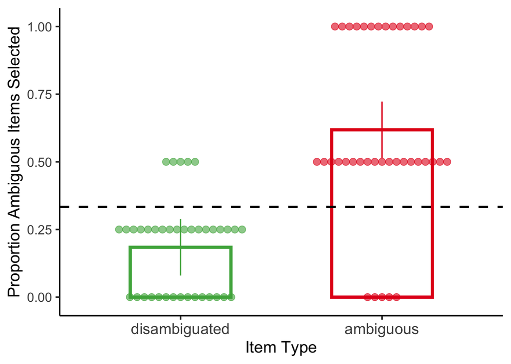

```r
##plot
ggplot(subj_summary_choiceType_2,aes(x=targetIsAmbiguousYN,y=ambiguous_choice,color=targetIsAmbiguousYN,fill=targetIsAmbiguousYN))+
  geom_bar(stat="identity",size=1.5,position=position_dodge(.53),width=0.5,alpha=0)+
  geom_dotplot(data=subj_test_choiceType_2,alpha=0.6,binaxis="y",stackdir="center",dotsize=0.8)+
  geom_errorbar(aes(ymin=lower_ci,ymax=upper_ci),width=0.0,size=0.6,position=position_dodge(.53))+
  scale_color_manual(name="Item Type",
                     limits=c("no","yes"),
                     labels=c("disambiguated","ambiguous"),
                     values=c("#4DAF4A","#E41A1C"))+
  scale_fill_manual(name="Item Type",
                    limits=c("no","yes"),
                    labels=c("disambiguated","ambiguous"),
                    values=c("#4DAF4A","#E41A1C"))+
  scale_x_discrete(name = "Item Type",
                   limits=c("no","yes"),
                   labels=c("disambiguated","ambiguous"))+
  ylab("Proportion Ambiguous Items Selected")+
  geom_hline(yintercept=1/3,linetype="dashed",size=1.1)+
  theme_classic(base_size=16)+
  theme(legend.position="none", axis.text.x=element_text(size=15))
```

#### Sampling and test accuracy

##### Overall Accuracy for Sampled vs. Not Sampled Items

```r
#summarize test accuracy by choice
subj_test_choice_2 <- d %>%
  filter(trialType=="test"&experiment_name  %in% c("Experiment 2")) %>%
  group_by(subject,experiment_name,ambiguity_condition,chosen) %>%
  summarize(
    N=n(),
    accuracy=mean(isRight,na.rm=T))

subj_summary_choice_2 <- summarySEwithin(
  subj_test_choice_2,
  "accuracy",
  betweenvars=c("experiment_name","ambiguity_condition"),
  withinvars=c("chosen"),
  idvar="subject",
  na.rm=T) %>%
  mutate(
    lower_ci = accuracy - ci,
    upper_ci = accuracy + ci,
    chosen_factor=ifelse(chosen==0,"NOT SAMPLED","SAMPLED")
  )
subj_summary_choice_2 %>%
  select(-accuracy_norm, -sd,-se,-ci) %>%
  kable()
```

| experiment_name | ambiguity_condition | chosen | N | accuracy | lower_ci | upper_ci | chosen_factor |
| --- | --- | --- | --- | --- | --- | --- | --- |
| Experiment 2 | ambiguous | 0 | 38 | 0.2675439 | 0.1621150 | 0.3729727 | NOT SAMPLED |
| Experiment 2 | ambiguous | 1 | 38 | 0.4517544 | 0.3463255 | 0.5571833 | SAMPLED |

##### Plot by Item Type

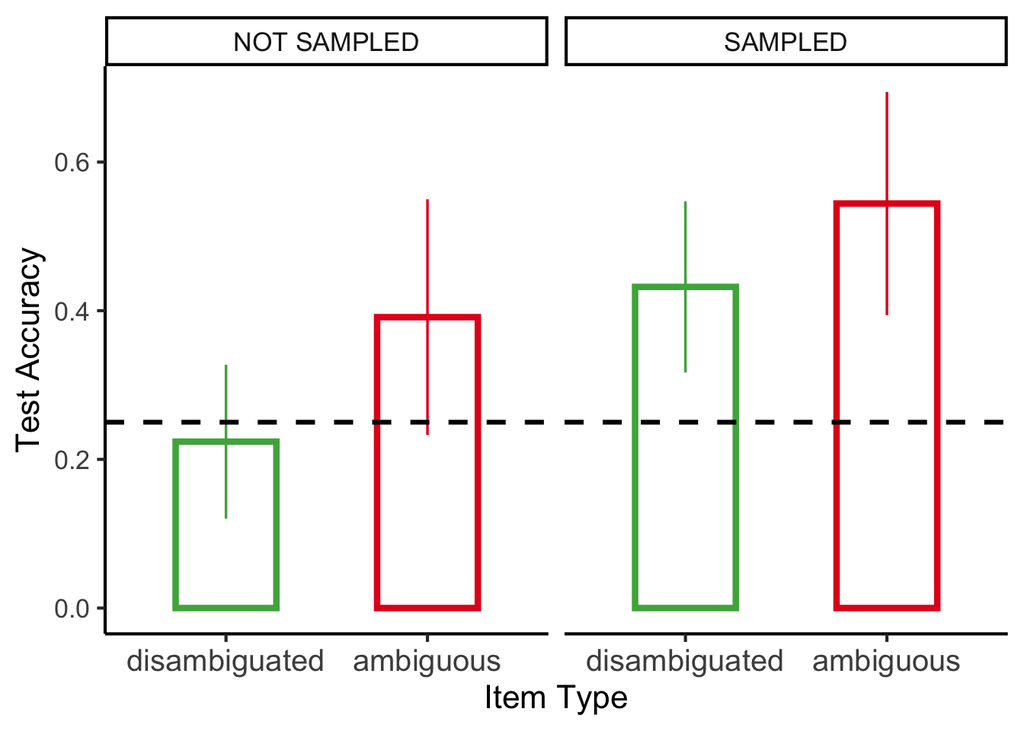

```r
subj_test_item_choice_2 <- d %>%
  filter(trialType=="test"&experiment_name  %in% c("Experiment 2")) %>%
  group_by(subject,experiment_name,ambiguity_condition,chosen,targetType,targetIsAmbiguous,targetIsAmbiguousYN) %>%
  summarize(
    N=n(),
    accuracy=mean(isRight,na.rm=T))

subj_summary_item_choice_2 <- summarySEwithin(
  subj_test_item_choice_2,
  "accuracy",
  betweenvars=c("experiment_name","ambiguity_condition"),
  withinvars=c("chosen","targetIsAmbiguousYN"),
  idvar="subject",
  na.rm=T) %>%
  mutate(
    lower_ci = accuracy - ci,
    upper_ci = accuracy + ci,
    chosen_factor=ifelse(chosen==0,"NOT SAMPLED","SAMPLED")
  )

ggplot(subj_summary_item_choice_2,aes(x=targetIsAmbiguousYN,y=accuracy,color=targetIsAmbiguousYN,fill=targetIsAmbiguousYN))+
  geom_bar(stat="identity",size=1.5,position=position_dodge(.53),width=0.5,alpha=0)+
  geom_errorbar(aes(ymin=lower_ci,ymax=upper_ci),width=0.0,size=0.6,position=position_dodge(.53))+
  scale_color_manual(name="Item Type",
                     limits=c("no","yes"),
                     labels=c("disambiguated","ambiguous"),
                     values=c("#4DAF4A","#E41A1C"))+
  scale_fill_manual(name="Item Type",
                    limits=c("no","yes"),
                    labels=c("disambiguated","ambiguous"),
                    values=c("#4DAF4A","#E41A1C"))+
  scale_x_discrete(name = "Item Type",
                   limits=c("no","yes"),
                   labels=c("disambiguated","ambiguous"))+
  ylab("Test Accuracy")+
  geom_hline(yintercept=1/4,linetype="dashed",size=1.1)+
  theme_classic(base_size=16)+
  theme(legend.position="none", axis.text.x=element_text(size=15))+
  facet_wrap(~chosen_factor)
```

##### Logistic Mixed-Effects Model

```r
d$chosenC <- ifelse(!is.na(d$chosen)&d$chosen==0,-0.5,
            ifelse(!is.na(d$chosen)&d$chosen==1,0.5,NA))
m <- glmer(isRight~targetIsAmbiguousC*chosenC+(1+targetIsAmbiguousC|subject)+(1|targetImage),data=subset(d,trialType=="test"&experiment_name=="Experiment 2"),family=binomial,glmerControl(optimizer="bobyqa",check.conv.singular="ignore"))
summary(m)
```

```
## Generalized linear mixed model fit by maximum likelihood (Laplace
##   Approximation) [glmerMod]
##  Family: binomial  ( logit )
## Formula: isRight ~ targetIsAmbiguousC * chosenC + (1 + targetIsAmbiguousC |
##     subject) + (1 | targetImage)
##    Data: subset(d, trialType == "test" & experiment_name == "Experiment 2")
## Control: glmerControl(optimizer = "bobyqa", check.conv.singular = "ignore")
##
##      AIC      BIC   logLik deviance df.resid
##    302.2    329.6   -143.1    286.2      219
##
## Scaled residuals:
##     Min      1Q  Median      3Q     Max
## -1.5720 -0.7516 -0.4534  0.9339  2.4960
##
## Random effects:
##  Groups      Name               Variance Std.Dev. Corr
##  subject     (Intercept)        0.44890  0.6700
##              targetIsAmbiguousC 0.03932  0.1983   -1.00
##  targetImage (Intercept)        0.00000  0.0000
## Number of obs: 227, groups:  subject, 38; targetImage, 6
##
## Fixed effects:
##                            Estimate Std. Error z value Pr(>|z|)
## (Intercept)                 -0.5662     0.2014  -2.811  0.00494 **
## targetIsAmbiguousC           0.8276     0.3441   2.405  0.01618 *
## chosenC                      0.8896     0.3349   2.656  0.00790 **
## targetIsAmbiguousC:chosenC  -0.4927     0.6997  -0.704  0.48135
## ---
## Signif. codes:  0 '***' 0.001 '**' 0.01 '*' 0.05 '.' 0.1 ' ' 1
##
## Correlation of Fixed Effects:
##             (Intr) trgIAC chosnC
## trgtIsAmbgC  0.048
## chosenC     -0.330  0.037
## trgtIsAmC:C  0.042 -0.412  0.158
```

```r
confint(m, method="Wald")[5:8,]
```

```
##                                 2.5 %    97.5 %
## (Intercept)                -0.9610699 -0.171419
## targetIsAmbiguousC          0.1530674  1.502058
## chosenC                     0.2332100  1.545923
## targetIsAmbiguousC:chosenC -1.8640073  0.878679
```

##### Correlation between overall sampling preference and test accuracy

```r
## preference for sampling ambiguous items and test performance
cor.test(subset(subj_selection,ambiguity_condition=="ambiguous"&experiment_name=="Experiment 2")$accuracy,subset(subj_selection,ambiguity_condition=="ambiguous"&experiment_name=="Experiment 2")$prop_ambig_selection)
```

```
##
##  Pearson's product-moment correlation
##
## data:  subset(subj_selection, ambiguity_condition == "ambiguous" & experiment_name ==  and subset(subj_selection, ambiguity_condition == "ambiguous" & experiment_name ==     "Experiment 2")$accuracy and     "Experiment 2")$prop_ambig_selection
## t = 1.3557, df = 36, p-value = 0.1836
## alternative hypothesis: true correlation is not equal to 0
## 95 percent confidence interval:
##  -0.1068138  0.5045310
## sample estimates:
##       cor
## 0.2203953
```

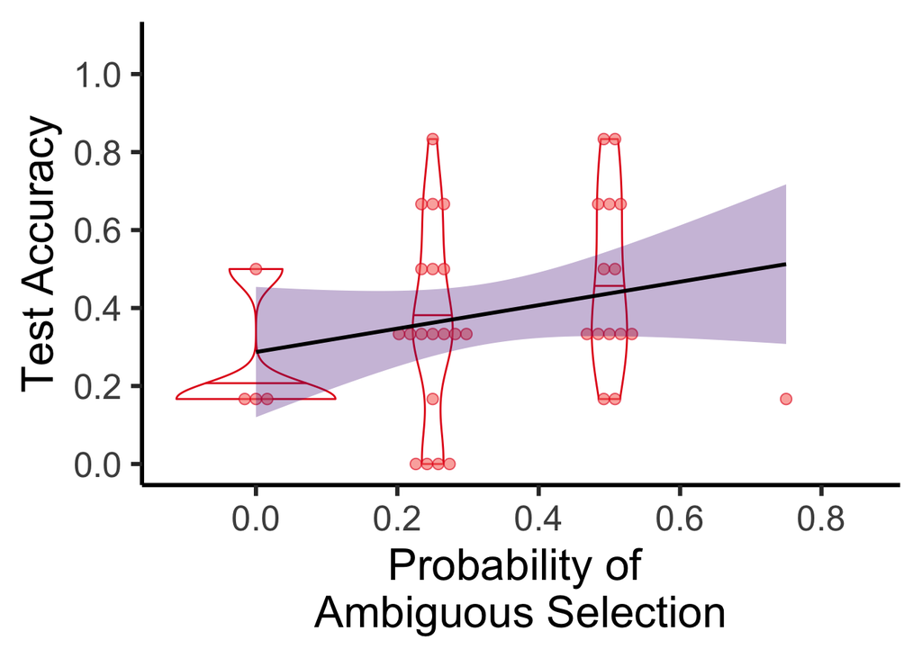

```r
##plot
ggplot(filter(subj_selection,experiment_name=="Experiment 2"),aes(prop_ambig_selection,accuracy, color=ambiguity_condition))+
  geom_violin(aes(group=prop_ambig_selection),draw_quantiles=c(0.5))+
  geom_dotplot(aes(group=prop_ambig_selection,fill=ambiguity_condition),alpha=0.6,binaxis="y",stackdir="center",dotsize=0.8)+
  scale_color_manual(limits=c("ambiguous"),
                     values=c("#E41A1C"))+
  geom_smooth(method="lm",color="black",fill="#4B0082",alpha=0.3)+
  theme_classic()+
  scale_x_continuous(breaks=c(0,0.2,0.4,0.6,0.8,1))+
  scale_y_continuous(breaks=c(0,0.2,0.4,0.6,0.8,1),limits=c(0,1.08))+
  theme_classic(base_size=24)+
  ylab("Test Accuracy")+
  theme(legend.position="none")+
  xlab("Probability of \nAmbiguous Selection")
```

## Experiment 3

### Sampling

Analysis of learners’ sampling preferences.

#### Plot

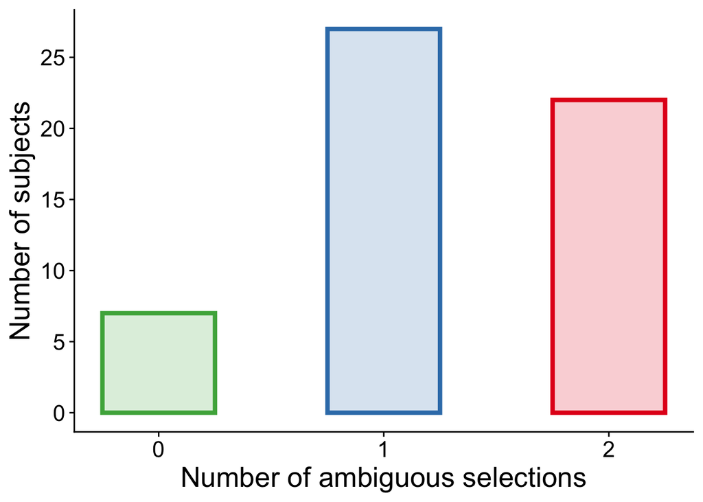

```r
ggplot(filter(subj_selection,experiment_name=="Experiment 3"),aes(x=num_ambig_selection,fill=as.factor(num_ambig_selection),color=as.factor(num_ambig_selection)))+
  scale_fill_brewer(palette="Set1",direction=-1)+
  scale_color_brewer(palette="Set1",direction=-1)+
  geom_bar(stat="count",size=1.5,alpha=0.2,width=0.5)+
  theme(axis.title = element_text(size=20),
        axis.text  = element_text(size=16),
        legend.position="none")+
  ylab("Number of subjects")+
  xlab("Number of ambiguous selections")+
  scale_x_continuous(breaks=c(0,1,2))+
  scale_y_continuous(breaks=c(0,5,10,15,20,25,30))
```

#### Descriptives

```r
#descriptives
subj_summary_3 <-  subj_selection %>%
  filter(experiment_name=="Experiment 3") %>%
  group_by(ambiguity_condition) %>%
  summarize(
    N=n(),
    prop_ambiguous=mean(prop_ambig_selection),
    ci_ambiguous=qt(0.975, N-1)*sd(prop_ambig_selection,na.rm=T)/sqrt(N),
    prop_ambiguous_lower_ci=prop_ambiguous-ci_ambiguous,
    prop_ambiguous_upper_ci=prop_ambiguous+ci_ambiguous,
  ) %>%
  select(-ci_ambiguous)
kable(subj_summary_3)
```

| ambiguity_condition | N | prop_ambiguous | prop_ambiguous_lower_ci | prop_ambiguous_upper_ci |
| --- | --- | --- | --- | --- |
| ambiguous_me | 56 | 0.6339286 | 0.5436849 | 0.7241723 |

#### Logistic mixed-effects model

```r
m=glmer(isAmbiguous ~ 1+(1|subject)+(1|choiceImage),data=subset(d,experiment_name=="Experiment 3"&trialType=="selection"),family=binomial,glmerControl(optimizer="bobyqa",check.conv.singular="ignore"))
summary(m)
```

```
## Generalized linear mixed model fit by maximum likelihood (Laplace
##   Approximation) [glmerMod]
##  Family: binomial  ( logit )
## Formula: isAmbiguous ~ 1 + (1 | subject) + (1 | choiceImage)
##    Data:
## subset(d, experiment_name == "Experiment 3" & trialType == "selection")
## Control: glmerControl(optimizer = "bobyqa", check.conv.singular = "ignore")
##
##      AIC      BIC   logLik deviance df.resid
##    153.1    161.3    -73.6    147.1      109
##
## Scaled residuals:
##     Min      1Q  Median      3Q     Max
## -1.3189 -1.3126  0.7582  0.7601  0.7618
##
## Random effects:
##  Groups      Name        Variance  Std.Dev.
##  subject     (Intercept) 2.663e-15 5.160e-08
##  choiceImage (Intercept) 1.529e-03 3.911e-02
## Number of obs: 112, groups:  subject, 56; choiceImage, 4
##
## Fixed effects:
##             Estimate Std. Error z value Pr(>|z|)
## (Intercept)   0.5498     0.2031   2.707  0.00679 **
## ---
## Signif. codes:  0 '***' 0.001 '**' 0.01 '*' 0.05 '.' 0.1 ' ' 1
```

```r
confint(m,method="Wald")[3,]
```

```
##     2.5 %    97.5 %
## 0.1517166 0.9479760
```

Note that we ignore a singular fit warning here. This appears to be caused by the inclusion of a by-item random intercept - however, it does not appear to adversely affect the model fit, and a simplified model with the by-stimulus random intercept removed yields virtually identical results.

#### Non-parametric test (Wilcoxon)

```r
wilcox.test(filter(subj_selection,experiment_name=="Experiment 3")$prop_ambig_selection,mu=1/2, conf.int=T, conf.level=0.95)
```

```
##
##  Wilcoxon signed rank test with continuity correction
##
## data:  filter(subj_selection, experiment_name == "Experiment 3")$prop_ambig_selection
## V = 330, p-value = 0.005553
## alternative hypothesis: true location is not equal to 0.5
## 95 percent confidence interval:
##  0.5000378 1.0000000
## sample estimates:
## (pseudo)median
##      0.9999326
```

#### Relationship with Age

```r
#predict ambiguous selections from age
m <- glmer(isAmbiguous~Age+(1|subject)+(1|choiceImage),data=subset(d,experiment_name=="Experiment 3"&trialType=="selection"),family=binomial)
summary(m)
```

```
## Generalized linear mixed model fit by maximum likelihood (Laplace
##   Approximation) [glmerMod]
##  Family: binomial  ( logit )
## Formula: isAmbiguous ~ Age + (1 | subject) + (1 | choiceImage)
##    Data:
## subset(d, experiment_name == "Experiment 3" & trialType == "selection")
##
##      AIC      BIC   logLik deviance df.resid
##    148.4    159.3    -70.2    140.4      108
##
## Scaled residuals:
##     Min      1Q  Median      3Q     Max
## -2.2833 -1.0456  0.5800  0.7368  1.2408
##
## Random effects:
##  Groups      Name        Variance  Std.Dev.
##  subject     (Intercept) 1.081e-08 0.000104
##  choiceImage (Intercept) 2.176e-03 0.046648
## Number of obs: 112, groups:  subject, 56; choiceImage, 4
##
## Fixed effects:
##             Estimate Std. Error z value Pr(>|z|)
## (Intercept)  -1.9284     1.0046  -1.919   0.0549 .
## Age           0.4551     0.1837   2.478   0.0132 *
## ---
## Signif. codes:  0 '***' 0.001 '**' 0.01 '*' 0.05 '.' 0.1 ' ' 1
##
## Correlation of Fixed Effects:
##     (Intr)
## Age -0.978
```

```r
confint(m, method="Wald")[3:4,]
```

```
##                   2.5 %     97.5 %
## (Intercept) -3.89741195 0.04068293
## Age          0.09510293 0.81512510
```

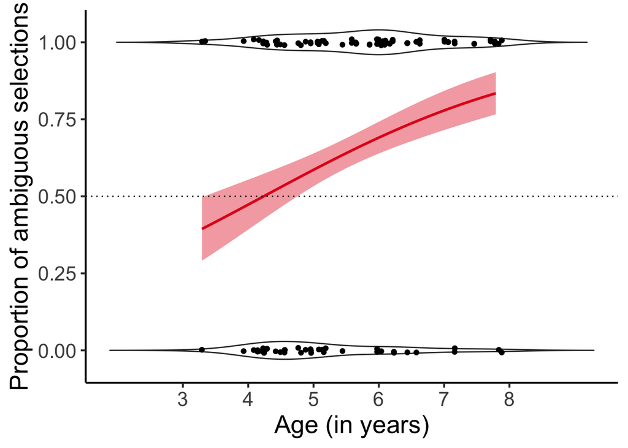

```r
#plot model predictions
pX <- data.frame(Age=seq(min(subset(d,experiment_name=="Experiment 3"&trialType=="selection")$Age,na.rm=T),max(subset(d,experiment_name=="Experiment 3"&trialType=="selection")$Age,na.rm=T),by=0.1))
pY <- predictSE(m,pX,re.form=NA,type="response")
pX$isAmbiguous <- pY$fit
pX$YLower <- pY$fit-pY$se.fit
pX$YUpper <- pY$fit+pY$se.fit
ggplot(pX,aes(Age,isAmbiguous))+
  geom_violinh(data=subset(d,experiment_name=="Experiment 3"&trialType=="selection"),aes(y=isAmbiguous,group=isAmbiguous),scale="count",width=0.1, trim=F)+
  geom_jitter(data=subset(d,experiment_name=="Experiment 3"&trialType=="selection"),aes(y=isAmbiguous,group=isAmbiguous),height=0.01)+
  geom_smooth(aes(ymin=YLower,ymax=YUpper),stat="identity",color="#E41A1C",fill="#E41A1C")+
  geom_hline(yintercept=0.5,linetype="dotted")+
  theme_classic(base_size=16)+
  xlab("Age (in years)")+
  scale_x_continuous(breaks=c(3,4,5,6,7,8))+
  ylab("Proportion of ambiguous selections")+
  theme(axis.title = element_text(size=20),
        axis.text  = element_text(size=16))
```

### Test

Analysis of learners’ test accuracy.

#### Plot

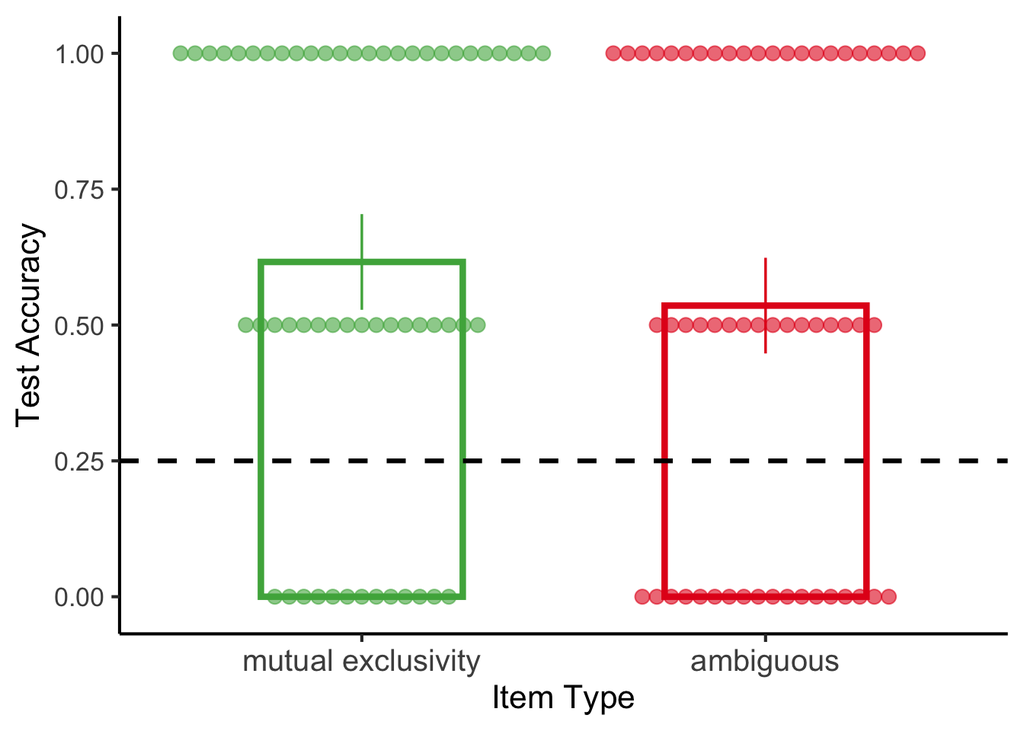

```r
##plot by item type
#by item type
subj_summary_item_3 <- summarySEwithin(
  filter(
    subj_test_item,
    (experiment_name=="Experiment 3")),
  "accuracy",
  betweenvars=c("experiment_name","ambiguity_condition"),
  withinvars=c("targetIsAmbiguousYN"),
  idvar="subject") %>%
  mutate(
    lower_ci = accuracy - ci,
    upper_ci = accuracy + ci
  )

ggplot(subj_summary_item_3,aes(x=targetIsAmbiguousYN,y=accuracy,color=targetIsAmbiguousYN,fill=targetIsAmbiguousYN))+
  geom_bar(stat="identity",size=1.5,position=position_dodge(.53),width=0.5,alpha=0)+
  geom_dotplot(data=filter(subj_test_item,experiment_name=="Experiment 3"),alpha=0.6,binaxis="y",stackdir="center",dotsize=0.8)+
  geom_errorbar(aes(ymin=lower_ci,ymax=upper_ci),width=0.0,size=0.6,position=position_dodge(.53))+
  scale_color_manual(name="Item Type",
                     limits=c("no","yes"),
                     labels=c("mutual exclusivity","ambiguous"),
                     values=c("#4DAF4A","#E41A1C"))+
  scale_fill_manual(name="Item Type",
                    limits=c("no","yes"),
                    labels=c("mutual exclusivity","ambiguous"),
                    values=c("#4DAF4A","#E41A1C"))+
  scale_x_discrete(name = "Item Type",
                   limits=c("no","yes"),
                   labels=c("mutual exclusivity","ambiguous"))+
  ylab("Test Accuracy")+
  geom_hline(yintercept=1/4,linetype="dashed",size=1.1)+
  theme_classic(base_size=16)+
  theme(legend.position="none", axis.text.x=element_text(size=15))
```

#### Descriptives

##### Overall Test Accuracy

```r
## descriptives
subj_summary_test_3 <-  subj_test %>%
  filter(experiment_name=="Experiment 3") %>%
  group_by(experiment_name,ambiguity_condition) %>%
  summarize(
    N=n(),
    prop_correct=mean(accuracy,na.rm=T),
    ci=qt(0.975, N-1)*sd(accuracy,na.rm=T)/sqrt(N),
    prop_correct_lower_ci=prop_correct-ci,
    prop_correct_upper_ci=prop_correct+ci)
subj_summary_test_3 %>%
  select(-ci) %>%
  kable()
```

| experiment_name | ambiguity_condition | N | prop_correct | prop_correct_lower_ci | prop_correct_upper_ci |
| --- | --- | --- | --- | --- | --- |
| Experiment 3 | ambiguous_me | 56 | 0.5758929 | 0.4839003 | 0.6678855 |

##### Test Accuracy Split by Item

```r
subj_summary_item_3 %>%
  select(-accuracy_norm,-se,-sd,-ci) %>%
  kable()
```

| experiment_name | ambiguity_condition | targetIsAmbiguousYN | N | accuracy | lower_ci | upper_ci |
| --- | --- | --- | --- | --- | --- | --- |
| Experiment 3 | ambiguous_me | no | 56 | 0.6160714 | 0.5280317 | 0.7041111 |
| Experiment 3 | ambiguous_me | yes | 56 | 0.5357143 | 0.4476746 | 0.6237540 |

#### Logistic Mixed-Effects Model

##### Overall Test Accuracy

```r
##logistic mixed-effects model
d$offset.25 <- 1/4
#overall
m <- glmer(isRight~offset(logit(offset.25))+(1|subject)+(1|targetImage),data=filter(d,experiment_name=="Experiment 3"&trialType=="test"),family=binomial)
summary(m)
```

```
## Generalized linear mixed model fit by maximum likelihood (Laplace
##   Approximation) [glmerMod]
##  Family: binomial  ( logit )
## Formula: isRight ~ offset(logit(offset.25)) + (1 | subject) + (1 | targetImage)
##    Data: filter(d, experiment_name == "Experiment 3" & trialType == "test")
##
##      AIC      BIC   logLik deviance df.resid
##    289.9    300.2   -142.0    283.9      221
##
## Scaled residuals:
##     Min      1Q  Median      3Q     Max
## -1.6324 -0.6345  0.3944  0.6126  1.2762
##
## Random effects:
##  Groups      Name        Variance Std.Dev.
##  subject     (Intercept) 2.17173  1.4737
##  targetImage (Intercept) 0.09708  0.3116
## Number of obs: 224, groups:  subject, 56; targetImage, 4
##
## Fixed effects:
##             Estimate Std. Error z value Pr(>|z|)
## (Intercept)   1.5272     0.3007   5.079 3.79e-07 ***
## ---
## Signif. codes:  0 '***' 0.001 '**' 0.01 '*' 0.05 '.' 0.1 ' ' 1
```

##### Test Accuracy by Item Type

```r
d$offset.25 <- 1/4
##logistic mixed-effects model
#by item type
m <- glmer(isRight~1+targetIsAmbiguousC+(1+targetIsAmbiguousC|subject)+(1|targetImage),data=filter(d,experiment_name=="Experiment 3"&trialType=="test"),family=binomial)
summary(m)
```

```
## Generalized linear mixed model fit by maximum likelihood (Laplace
##   Approximation) [glmerMod]
##  Family: binomial  ( logit )
## Formula: isRight ~ 1 + targetIsAmbiguousC + (1 + targetIsAmbiguousC |
##     subject) + (1 | targetImage)
##    Data: filter(d, experiment_name == "Experiment 3" & trialType == "test")
##
##      AIC      BIC   logLik deviance df.resid
##    293.5    314.0   -140.8    281.5      218
##
## Scaled residuals:
##     Min      1Q  Median      3Q     Max
## -1.7428 -0.6127  0.3710  0.5865  1.3274
##
## Random effects:
##  Groups      Name               Variance Std.Dev. Corr
##  subject     (Intercept)        2.5206   1.5876
##              targetIsAmbiguousC 0.7476   0.8646   0.39
##  targetImage (Intercept)        0.1001   0.3164
## Number of obs: 224, groups:  subject, 56; targetImage, 4
##
## Fixed effects:
##                    Estimate Std. Error z value Pr(>|z|)
## (Intercept)          0.4427     0.3168   1.397    0.162
## targetIsAmbiguousC  -0.4392     0.3615  -1.215    0.224
##
## Correlation of Fixed Effects:
##             (Intr)
## trgtIsAmbgC 0.064
```

```r
confint(m,method="Wald")[5:6,]
```

```
##                         2.5 %    97.5 %
## (Intercept)        -0.1781934 1.0636353
## targetIsAmbiguousC -1.1478162 0.2693513
```

#### Sampling and test accuracy

##### Overall Accuracy for Sampled vs. Not Sampled Items

```r
#summarize test accuracy by choice
subj_test_choice_3 <- d %>%
  filter(trialType=="test"&experiment_name  %in% c("Experiment 3")) %>%
  group_by(subject,experiment_name,ambiguity_condition,chosen) %>%
  summarize(
    N=n(),
    accuracy=mean(isRight,na.rm=T))

subj_summary_choice_3 <- summarySEwithin(
  subj_test_choice_3,
  "accuracy",
  betweenvars=c("experiment_name","ambiguity_condition"),
  withinvars=c("chosen"),
  idvar="subject",
  na.rm=T) %>%
  mutate(
    lower_ci = accuracy - ci,
    upper_ci = accuracy + ci,
    chosen_factor=ifelse(chosen==0,"NOT SAMPLED","SAMPLED")
  )
subj_summary_choice_3 %>%
  select(-accuracy_norm, -sd,-se,-ci) %>%
  kable()
```

| experiment_name | ambiguity_condition | chosen | N | accuracy | lower_ci | upper_ci | chosen_factor |
| --- | --- | --- | --- | --- | --- | --- | --- |
| Experiment 3 | ambiguous_me | 0 | 56 | 0.5595238 | 0.4653227 | 0.6537249 | NOT SAMPLED |
| Experiment 3 | ambiguous_me | 1 | 56 | 0.5982143 | 0.5040132 | 0.6924154 | SAMPLED |

##### Plot by Item Type

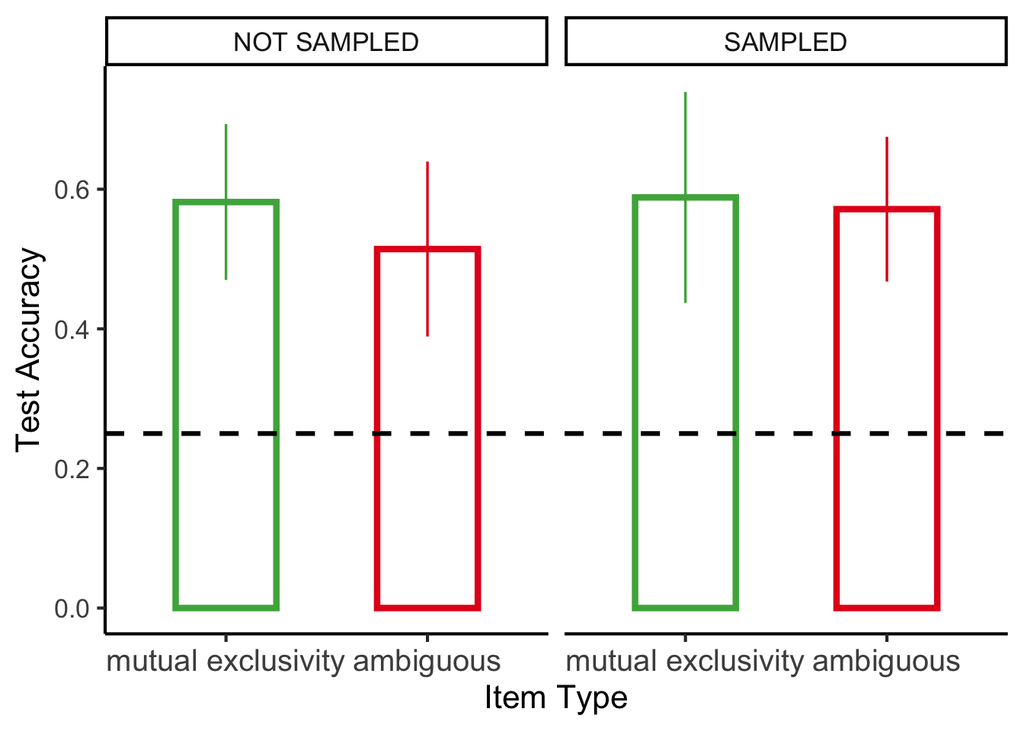

```r
subj_test_item_choice_3 <- d %>%
  filter(trialType=="test"&experiment_name  %in% c("Experiment 3")) %>%
  group_by(subject,experiment_name,ambiguity_condition,chosen,targetType,targetIsAmbiguous,targetIsAmbiguousYN) %>%
  summarize(
    N=n(),
    accuracy=mean(isRight,na.rm=T))

subj_summary_item_choice_3 <- summarySEwithin(
  subj_test_item_choice_3,
  "accuracy",
  betweenvars=c("experiment_name","ambiguity_condition"),
  withinvars=c("chosen","targetIsAmbiguousYN"),
  idvar="subject",
  na.rm=T) %>%
  mutate(
    lower_ci = accuracy - ci,
    upper_ci = accuracy + ci,
    chosen_factor=ifelse(chosen==0,"NOT SAMPLED","SAMPLED")
  )

ggplot(subj_summary_item_choice_3,aes(x=targetIsAmbiguousYN,y=accuracy,color=targetIsAmbiguousYN,fill=targetIsAmbiguousYN))+
  geom_bar(stat="identity",size=1.5,position=position_dodge(.53),width=0.5,alpha=0)+
  geom_errorbar(aes(ymin=lower_ci,ymax=upper_ci),width=0.0,size=0.6,position=position_dodge(.53))+
  scale_color_manual(name="Item Type",
                     limits=c("no","yes"),
                     labels=c("mutual exclusivity","ambiguous"),
                     values=c("#4DAF4A","#E41A1C"))+
  scale_fill_manual(name="Item Type",
                    limits=c("no","yes"),
                    labels=c("mutual exclusivity","ambiguous"),
                    values=c("#4DAF4A","#E41A1C"))+
  scale_x_discrete(name = "Item Type",
                   limits=c("no","yes"),
                   labels=c("mutual exclusivity","ambiguous"))+
  ylab("Test Accuracy")+
  geom_hline(yintercept=1/4,linetype="dashed",size=1.1)+
  theme_classic(base_size=16)+
  theme(legend.position="none", axis.text.x=element_text(size=15))+
  facet_wrap(~chosen_factor)
```

##### Logistic Mixed-Effects Model

```r
m <- glmer(isRight~targetIsAmbiguousC*chosenC+(1+targetIsAmbiguousC|subject)+(1|targetImage),data=subset(d,trialType=="test"&experiment_name=="Experiment 3"),family=binomial,glmerControl(optimizer="bobyqa"))
summary(m)
```

```
## Generalized linear mixed model fit by maximum likelihood (Laplace
##   Approximation) [glmerMod]
##  Family: binomial  ( logit )
## Formula: isRight ~ targetIsAmbiguousC * chosenC + (1 + targetIsAmbiguousC |
##     subject) + (1 | targetImage)
##    Data: subset(d, trialType == "test" & experiment_name == "Experiment 3")
## Control: glmerControl(optimizer = "bobyqa")
##
##      AIC      BIC   logLik deviance df.resid
##    296.5    323.8   -140.3    280.5      216
##
## Scaled residuals:
##     Min      1Q  Median      3Q     Max
## -1.9202 -0.6319  0.3743  0.5870  1.5328
##
## Random effects:
##  Groups      Name               Variance Std.Dev. Corr
##  subject     (Intercept)        2.47115  1.5720
##              targetIsAmbiguousC 0.52951  0.7277   0.38
##  targetImage (Intercept)        0.09831  0.3135
## Number of obs: 224, groups:  subject, 56; targetImage, 4
##
## Fixed effects:
##                            Estimate Std. Error z value Pr(>|z|)
## (Intercept)                  0.4250     0.3188   1.333    0.182
## targetIsAmbiguousC          -0.5291     0.3671  -1.441    0.150
## chosenC                      0.3414     0.3474   0.983    0.326
## targetIsAmbiguousC:chosenC   0.2390     0.8039   0.297    0.766
##
## Correlation of Fixed Effects:
##             (Intr) trgIAC chosnC
## trgtIsAmbgC  0.045
## chosenC      0.001 -0.255
## trgtIsAmC:C -0.164  0.003  0.031
```

```r
confint(m, method="Wald")[5:8,]
```

```
##                                 2.5 %    97.5 %
## (Intercept)                -0.1997402 1.0497618
## targetIsAmbiguousC         -1.2487101 0.1904759
## chosenC                    -0.3395635 1.0223851
## targetIsAmbiguousC:chosenC -1.3365340 1.8145833
```

##### Correlation between overall sampling preference and test accuracy

```r
##relationship between sampling preference for ambiguous items and test accuracy
cor.test(subset(subj_selection,ambiguity_condition=="ambiguous_me"&experiment_name=="Experiment 3")$accuracy,subset(subj_selection,ambiguity_condition=="ambiguous_me"&experiment_name=="Experiment 3")$prop_ambig_selection)
```

```
##
##  Pearson's product-moment correlation
##
## data:  subset(subj_selection, ambiguity_condition == "ambiguous_me" &  and subset(subj_selection, ambiguity_condition == "ambiguous_me" &     experiment_name == "Experiment 3")$accuracy and     experiment_name == "Experiment 3")$prop_ambig_selection
## t = 0.49839, df = 54, p-value = 0.6202
## alternative hypothesis: true correlation is not equal to 0
## 95 percent confidence interval:
##  -0.1987701  0.3247892
## sample estimates:
##        cor
## 0.06766648
```

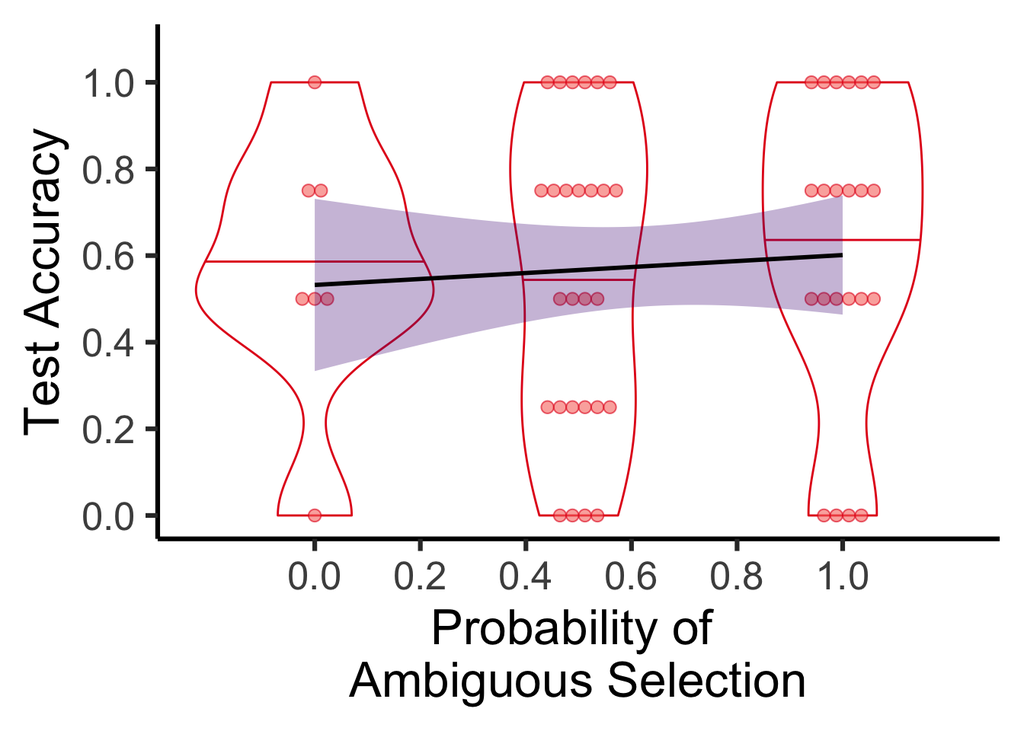

```r
##plot
ggplot(filter(subj_selection,experiment_name=="Experiment 3"),aes(prop_ambig_selection,accuracy, color=ambiguity_condition))+
  geom_violin(aes(group=prop_ambig_selection),draw_quantiles=c(0.5))+
  geom_dotplot(aes(group=prop_ambig_selection,fill=ambiguity_condition),alpha=0.6,binaxis="y",stackdir="center",dotsize=0.8)+
  scale_color_manual(limits=c("ambiguous_me"),
                     values=c("#E41A1C"))+
  geom_smooth(method="lm",color="black",fill="#4B0082",alpha=0.3)+
  theme_classic()+
  scale_x_continuous(breaks=c(0,0.2,0.4,0.6,0.8,1))+
  scale_y_continuous(breaks=c(0,0.2,0.4,0.6,0.8,1),limits=c(0,1.08))+
  theme_classic(base_size=24)+
  ylab("Test Accuracy")+
  theme(legend.position="none")+
  xlab("Probability of \nAmbiguous Selection")
```

## Experiment S1

### Sampling

Analysis of learners’ sampling preferences.

#### Plot

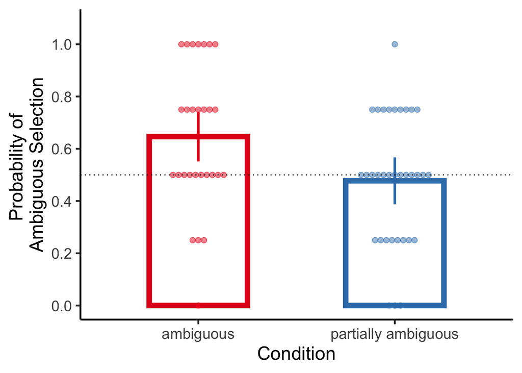

```r
## Plot
d$conditionFull <- ifelse(d$ambiguity_condition=="ambiguous",0,
                          ifelse(d$ambiguity_condition=="partially ambiguous",-1,NA))
m <- glmer(isAmbiguous~conditionFull+(1|subject)+(1|choiceImage),data=subset(d,experiment_name=="Experiment S1"&trialType=="selection"),family=binomial, glmerControl(optimizer="bobyqa",check.conv.singular="ignore"))
model_pred <- data.frame(conditionFull=c(-1,0),ambiguity_condition=c("partially ambiguous","ambiguous"))
pY <- predictSE(m,model_pred, type="response")
model_pred <- model_pred %>%
  mutate(
    prop_ambiguous = pY$fit,
    prop_ambiguous_lower_ci = pY$fit - 1.96*pY$se.fit,
    prop_ambiguous_upper_ci = pY$fit + 1.96*pY$se.fit)
p_expS1_sampling <- ggplot(model_pred,aes(x=ambiguity_condition,y=prop_ambiguous,color=ambiguity_condition,fill=ambiguity_condition))+
  geom_bar(stat="identity",size=2.5,fill="white",width=0.5)+
  geom_dotplot(data=subset(subj_selection,experiment_name=="Experiment S1"), aes(y=prop_ambig_selection),binaxis="y",stackdir="center",alpha=0.5,dotsize=0.6)+
  geom_errorbar(aes(ymin=prop_ambiguous_lower_ci,ymax=prop_ambiguous_upper_ci),width=0,size=1.2)+
  ylab("Probability of \nAmbiguous Selection")+
  geom_hline(yintercept=0.5,linetype="dotted")+
  scale_y_continuous(breaks=c(0,0.2,0.4,0.6,0.8,1),limits=c(0,1.08))+
  scale_color_brewer(palette="Set1")+
  scale_fill_brewer(palette="Set1")+
  theme_classic(base_size=18)+
  theme(legend.position="none")+
  scale_x_discrete(name="Condition")
p_expS1_sampling
```

#### Descriptives

```r
#descriptives
subj_summary_s1 <-  subj_selection %>%
  filter(experiment_name=="Experiment S1") %>%
  group_by(ambiguity_condition) %>%
  summarize(
    N=n(),
    prop_ambiguous=mean(prop_ambig_selection),
    ci_ambiguous=qt(0.975, N-1)*sd(prop_ambig_selection,na.rm=T)/sqrt(N),
    prop_ambiguous_lower_ci=prop_ambiguous-ci_ambiguous,
    prop_ambiguous_upper_ci=prop_ambiguous+ci_ambiguous,
  ) %>%
  select(-ci_ambiguous)
kable(subj_summary_s1)
```

| ambiguity_condition | N | prop_ambiguous | prop_ambiguous_lower_ci | prop_ambiguous_upper_ci |
| --- | --- | --- | --- | --- |
| ambiguous | 28 | 0.6428571 | 0.5359183 | 0.7497960 |
| partially ambiguous | 34 | 0.4779412 | 0.3910626 | 0.5648197 |

#### Logistic mixed-effects model

##### Condition Comparison

Estimating the difference in preference for selecting ambiguous items in the Partially Ambiguous condition vs. the Fully Ambiguous condition.

```r
d$conditionC <- ifelse(d$ambiguity_condition=="ambiguous",0.5,
                       ifelse(d$ambiguity_condition=="partially ambiguous",-0.5,NA))
m <- glmer(isAmbiguous~conditionC+(1|subject)+(1|choiceImage),data=subset(d,(experiment_name=="Experiment S1")&trialType=="selection"),family=binomial,glmerControl(check.conv.singular="ignore"))
summary(m)
```

```
## Generalized linear mixed model fit by maximum likelihood (Laplace
##   Approximation) [glmerMod]
##  Family: binomial  ( logit )
## Formula: isAmbiguous ~ conditionC + (1 | subject) + (1 | choiceImage)
##    Data: subset(d, (experiment_name == "Experiment S1") & trialType ==
##     "selection")
## Control: glmerControl(check.conv.singular = "ignore")
##
##      AIC      BIC   logLik deviance df.resid
##      342      356     -167      334      244
##
## Scaled residuals:
##     Min      1Q  Median      3Q     Max
## -1.3825 -0.9601  0.6865  0.9394  1.0968
##
## Random effects:
##  Groups      Name        Variance  Std.Dev.
##  subject     (Intercept) 1.151e-01 3.393e-01
##  choiceImage (Intercept) 8.752e-10 2.958e-05
## Number of obs: 248, groups:  subject, 62; choiceImage, 8
##
## Fixed effects:
##             Estimate Std. Error z value Pr(>|z|)
## (Intercept)   0.2569     0.1401   1.833   0.0668 .
## conditionC    0.6955     0.2815   2.471   0.0135 *
## ---
## Signif. codes:  0 '***' 0.001 '**' 0.01 '*' 0.05 '.' 0.1 ' ' 1
##
## Correlation of Fixed Effects:
##            (Intr)
## conditionC 0.145
```

```r
confint(m,method="Wald")[3:4,]
```

```
##                   2.5 %    97.5 %
## (Intercept) -0.01777231 0.5315834
## conditionC   0.14384157 1.2472401
```

##### Fully Ambiguous Condition

Estimating the preference for (fully) ambiguous items by re-centering the model on the fully ambiguous condition. The intercept represents the preference for selecting ambiguous items in the Fully Ambiguous condition.

```r
## Fully Ambiguous Condition
d$conditionFull <- ifelse(d$ambiguity_condition=="ambiguous",0,
                          ifelse(d$ambiguity_condition=="partially ambiguous",-1,NA))

m <- glmer(isAmbiguous~conditionFull+(1|subject)+(1|choiceImage),data=subset(d,experiment_name=="Experiment S1"&trialType=="selection"),family=binomial,glmerControl(check.conv.singular="ignore"))
summary(m)
```

```
## Generalized linear mixed model fit by maximum likelihood (Laplace
##   Approximation) [glmerMod]
##  Family: binomial  ( logit )
## Formula: isAmbiguous ~ conditionFull + (1 | subject) + (1 | choiceImage)
##    Data:
## subset(d, experiment_name == "Experiment S1" & trialType == "selection")
## Control: glmerControl(check.conv.singular = "ignore")
##
##      AIC      BIC   logLik deviance df.resid
##      342      356     -167      334      244
##
## Scaled residuals:
##     Min      1Q  Median      3Q     Max
## -1.3825 -0.9601  0.6865  0.9394  1.0968
##
## Random effects:
##  Groups      Name        Variance Std.Dev.
##  subject     (Intercept) 0.1151   0.3393
##  choiceImage (Intercept) 0.0000   0.0000
## Number of obs: 248, groups:  subject, 62; choiceImage, 8
##
## Fixed effects:
##               Estimate Std. Error z value Pr(>|z|)
## (Intercept)     0.6047     0.2125   2.845  0.00444 **
## conditionFull   0.6955     0.2815   2.471  0.01347 *
## ---
## Signif. codes:  0 '***' 0.001 '**' 0.01 '*' 0.05 '.' 0.1 ' ' 1
##
## Correlation of Fixed Effects:
##             (Intr)
## conditinFll 0.758
```

```r
confint(m,method="Wald")[3:4,]
```

```
##                   2.5 %   97.5 %
## (Intercept)   0.1881258 1.021231
## conditionFull 0.1438395 1.247238
```

##### Partially Ambiguous Condition

Estimating the preference for (partially) ambiguous items by re-centering the model on the partially ambiguous condition. The intercept represents the preference for selecting ambiguous items in the Partially Ambiguous condition.

```r
d$conditionPartial <- ifelse(d$ambiguity_condition=="ambiguous",1,
                            ifelse(d$ambiguity_condition=="partially ambiguous",0,NA))

m <- glmer(isAmbiguous~conditionPartial+(1|subject)+(1|choiceImage),data=subset(d,experiment_name=="Experiment S1"&trialType=="selection"),family=binomial,glmerControl(check.conv.singular="ignore"))
summary(m)
```

```
## Generalized linear mixed model fit by maximum likelihood (Laplace
##   Approximation) [glmerMod]
##  Family: binomial  ( logit )
## Formula: isAmbiguous ~ conditionPartial + (1 | subject) + (1 | choiceImage)
##    Data:
## subset(d, experiment_name == "Experiment S1" & trialType == "selection")
## Control: glmerControl(check.conv.singular = "ignore")
##
##      AIC      BIC   logLik deviance df.resid
##      342      356     -167      334      244
##
## Scaled residuals:
##     Min      1Q  Median      3Q     Max
## -1.3825 -0.9601  0.6865  0.9394  1.0968
##
## Random effects:
##  Groups      Name        Variance Std.Dev.
##  subject     (Intercept) 0.1151   0.3393
##  choiceImage (Intercept) 0.0000   0.0000
## Number of obs: 248, groups:  subject, 62; choiceImage, 8
##
## Fixed effects:
##                  Estimate Std. Error z value Pr(>|z|)
## (Intercept)      -0.09086    0.18365  -0.495   0.6208
## conditionPartial  0.69553    0.28148   2.471   0.0135 *
## ---
## Signif. codes:  0 '***' 0.001 '**' 0.01 '*' 0.05 '.' 0.1 ' ' 1
##
## Correlation of Fixed Effects:
##             (Intr)
## conditnPrtl -0.656
```

```r
confint(m,method="Wald")[3:4,]
```

```
##                       2.5 %    97.5 %
## (Intercept)      -0.4508106 0.2690974
## conditionPartial  0.1438339 1.2472347
```

#### Non-parametric test (Wilcoxon)

##### Condition Comparison

```r
##condition comparison
wilcox.test(subset(subj_selection , ambiguity_condition=="ambiguous"&experiment_name=="Experiment S1")$prop_ambig_selection,
            subset(subj_selection, ambiguity_condition=="partially ambiguous"&experiment_name=="Experiment S1")$prop_ambig_selection,
            conf.int=T, conf.level=0.95)
```

```
##
##  Wilcoxon rank sum test with continuity correction
##
## data:  subset(subj_selection, ambiguity_condition == "ambiguous" & experiment_name ==  and subset(subj_selection, ambiguity_condition == "partially ambiguous" &     "Experiment S1")$prop_ambig_selection and     experiment_name == "Experiment S1")$prop_ambig_selection
## W = 631.5, p-value = 0.02256
## alternative hypothesis: true location shift is not equal to 0
## 95 percent confidence interval:
##  2.599459e-05 2.500091e-01
## sample estimates:
## difference in location
##              0.2499557
```

##### Fully Ambiguous Condition

```r
##Fully Ambiguous Condition
wilcox.test(subset(subj_selection, experiment_name=="Experiment S1"&ambiguity_condition=="ambiguous")$prop_ambig_selection,mu=1/2, conf.int=T, conf.level=0.95)
```

```
##
##  Wilcoxon signed rank test with continuity correction
##
## data:  subset(subj_selection, experiment_name == "Experiment S1" & ambiguity_condition ==     "ambiguous")$prop_ambig_selection
## V = 140, p-value = 0.01534
## alternative hypothesis: true location is not equal to 0.5
## 95 percent confidence interval:
##  0.5000486 0.8750296
## sample estimates:
## (pseudo)median
##       0.750061
```

##### Partially Ambiguous Condition

```r
##Partially Ambiguous Condition
wilcox.test(subset(subj_selection, experiment_name=="Experiment S1"&ambiguity_condition=="partially ambiguous")$prop_ambig_selection,mu=1/2, conf.int=T, conf.level=0.95)
```

```
##
##  Wilcoxon signed rank test with continuity correction
##
## data:  subset(subj_selection, experiment_name == "Experiment S1" & ambiguity_condition ==     "partially ambiguous")$prop_ambig_selection
## V = 100.5, p-value = 0.5901
## alternative hypothesis: true location is not equal to 0.5
## 95 percent confidence interval:
##  0.2500428 0.6249926
## sample estimates:
## (pseudo)median
##      0.4999225
```

### Test

Analysis of learners’ test performance.

```r
##summarize participant accuracy by test half
subj_test_half <- d %>%
  filter(trialType=="test"&experiment_name=="Experiment S1") %>%
  group_by(subject,experiment_name,ambiguity_condition, testHalf) %>%
  summarize(
    N=n(),
    accuracy=mean(isRight,na.rm=T))
##by item and test half
subj_test_half_item <- d %>%
  filter(trialType=="test"&experiment_name=="Experiment S1") %>%
  group_by(subject,experiment_name,ambiguity_condition, testHalf,targetType,targetIsAmbiguous,targetIsAmbiguousYN) %>%
  summarize(
    N=n(),
    accuracy=mean(isRight,na.rm=T))
```

#### Plot

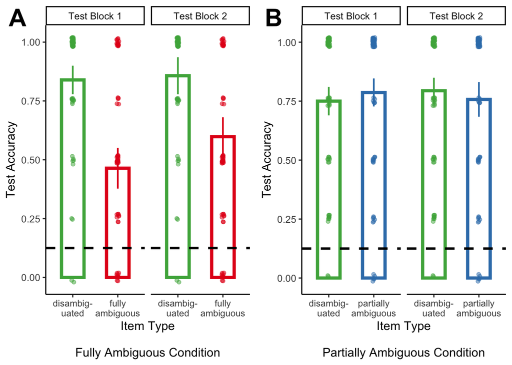

```r
#item summary within-subjects corrected CIs
subj_summary_item_testhalf_correctedCIs_s1 <- summarySEwithin(
  filter(
    subj_test_half_item,
    (experiment_name=="Experiment S1")),
  "accuracy",
  betweenvars=c("experiment_name","ambiguity_condition"),
  withinvars=c("testHalf","targetIsAmbiguousYN"),
  idvar="subject") %>%
  mutate(
    lower_ci = accuracy - ci,
    upper_ci = accuracy + ci,
    testHalf_name = paste("Test Block",testHalf,sep=" ")
  )

#Experiment S1 - test
p_expS1_fulltest <- ggplot(filter(subj_summary_item_testhalf_correctedCIs_s1,ambiguity_condition=="ambiguous"),aes(x=targetIsAmbiguousYN,y=accuracy,color=targetIsAmbiguousYN,fill=targetIsAmbiguousYN))+
  geom_bar(stat="identity",size=1.5,position=position_dodge(.53),width=0.5,alpha=0)+
  geom_point(data=filter(subj_test_half_item,experiment_name=="Experiment S1"&ambiguity_condition=="ambiguous"),aes(fill=targetIsAmbiguousYN),alpha=0.5,position=position_jitterdodge(dodge.width=0.53,jitter.width=0.1,jitter.height=0.02))+
  geom_errorbar(aes(ymin=lower_ci,ymax=upper_ci),width=0.0,size=0.8,position=position_dodge(.53))+
  scale_color_manual(name="Item Type",
                     limits=c("no","yes"),
                     labels=c("disambiguated","ambiguous"),
                     values=c("#4DAF4A","#E41A1C"))+
  scale_fill_manual(name="Item Type",
                    limits=c("no","yes"),
                    labels=c("disambiguated","ambiguous"),
                    values=c("#4DAF4A","#E41A1C"))+
  scale_x_discrete(name = "Item Type\n\nFully Ambiguous Condition",
                   limits=c("no","yes"),
                   labels=c("disambig-\nuated","fully\nambiguous"))+
  ylab("Test Accuracy")+
  geom_hline(yintercept=1/8,linetype="dashed",size=1.1)+
  theme_classic(base_size=12)+
  theme(legend.position="none", axis.text.x=element_text(size=9))+
  facet_wrap(~testHalf_name)

p_expS1_partialtest <- ggplot(filter(subj_summary_item_testhalf_correctedCIs_s1, ambiguity_condition=="partially ambiguous"),aes(x=targetIsAmbiguousYN,y=accuracy,color=targetIsAmbiguousYN,fill=targetIsAmbiguousYN))+
  geom_bar(stat="identity",size=1.5,position=position_dodge(.53),width=0.5,alpha=0)+
  geom_point(data=filter(subj_test_half_item,experiment_name=="Experiment S1"&ambiguity_condition=="partially ambiguous"),aes(fill=targetIsAmbiguousYN),alpha=0.5,position=position_jitterdodge(dodge.width=0.53,jitter.width=0.1,jitter.height=0.02))+
  geom_errorbar(aes(ymin=lower_ci,ymax=upper_ci),width=0.0,size=0.8,position=position_dodge(.53))+
  scale_color_manual(name="Item Type",
                     limits=c("no","yes"),
                     labels=c("disambiguated","partially\nambiguous"),
                     values=c("#4DAF4A","#377EB8"))+
  scale_fill_manual(name="Item Type",
                    limits=c("no","yes"),
                    labels=c("disambiguated","partially\nambiguous"),
                    values=c("#4DAF4A","#377EB8"))+
  scale_x_discrete(name = "Item Type\n\nPartially Ambiguous Condition",
                   limits=c("no","yes"),
                   labels=c("disambig-\nuated","partially\nambiguous"))+
  ylab("Test Accuracy")+
  geom_hline(yintercept=1/8,linetype="dashed",size=1.1)+
  theme_classic(base_size=12)+
  theme(legend.position="none", axis.text.x=element_text(size=9))+
  facet_wrap(~testHalf_name)
plot_grid(p_expS1_fulltest,p_expS1_partialtest, labels=c("A","B"),rel_widths=c(1,1),label_size=24,nrow=1)
```

#### Descriptives

##### Overall Test Accuracy

Split by test half.

```r
## descriptives
subj_summary_test_s1 <-  summarySEwithin(
  subj_test_half,
  "accuracy",
  betweenvars=c("experiment_name","ambiguity_condition"),
  withinvars=c("testHalf"),
  idvar="subject") %>%
  mutate(
    lower_ci = accuracy - ci,
    upper_ci = accuracy + ci,
    testHalf_name = paste("Test Block",testHalf,sep=" ")
  ) %>%
  select(-accuracy_norm,-se,-sd,-ci)

kable(subj_summary_test_s1)
```

| experiment_name | ambiguity_condition | testHalf | N | accuracy | lower_ci | upper_ci | testHalf_name |
| --- | --- | --- | --- | --- | --- | --- | --- |
| Experiment S1 | ambiguous | 1 | 28 | 0.6517857 | 0.6118389 | 0.6917325 | Test Block 1 |
| Experiment S1 | ambiguous | 2 | 28 | 0.7276786 | 0.6877318 | 0.7676254 | Test Block 2 |
| Experiment S1 | partially ambiguous | 1 | 34 | 0.7683824 | 0.7248067 | 0.8119580 | Test Block 1 |
| Experiment S1 | partially ambiguous | 2 | 34 | 0.7757353 | 0.7321596 | 0.8193110 | Test Block 2 |

##### Test Accuracy Split by Item

Split by test half.

```r
## split by item
subj_summary_test_item_s1 <-  summarySEwithin(
  subj_test_half_item,
  "accuracy",
  betweenvars=c("experiment_name","ambiguity_condition"),
  withinvars=c("testHalf","targetIsAmbiguousYN"),
  idvar="subject") %>%
  mutate(
    lower_ci = accuracy - ci,
    upper_ci = accuracy + ci,
    testHalf_name = paste("Test Block",testHalf,sep=" ")
  ) %>%
  select(-accuracy_norm,-se,-sd,-ci)

kable(subj_summary_test_item_s1)
```

| experiment_name | ambiguity_condition | testHalf | targetIsAmbiguousYN | N | accuracy | lower_ci | upper_ci | testHalf_name |
| --- | --- | --- | --- | --- | --- | --- | --- | --- |
| Experiment S1 | ambiguous | 1 | no | 28 | 0.8392857 | 0.7786705 | 0.8999009 | Test Block 1 |
| Experiment S1 | ambiguous | 1 | yes | 28 | 0.4642857 | 0.3776673 | 0.5509041 | Test Block 1 |
| Experiment S1 | ambiguous | 2 | no | 28 | 0.8571429 | 0.7783393 | 0.9359464 | Test Block 2 |
| Experiment S1 | ambiguous | 2 | yes | 28 | 0.5982143 | 0.5156617 | 0.6807669 | Test Block 2 |
| Experiment S1 | partially ambiguous | 1 | no | 34 | 0.7500000 | 0.6896160 | 0.8103840 | Test Block 1 |
| Experiment S1 | partially ambiguous | 1 | yes | 34 | 0.7867647 | 0.7272860 | 0.8462434 | Test Block 1 |
| Experiment S1 | partially ambiguous | 2 | no | 34 | 0.7941176 | 0.7390598 | 0.8491754 | Test Block 2 |
| Experiment S1 | partially ambiguous | 2 | yes | 34 | 0.7573529 | 0.6839887 | 0.8307171 | Test Block 2 |

#### Logistic mixed-effects model

##### Three-Way Interaction: Effects of Item Type and Test Half across Conditions

```r
d$testHalfC <- ifelse(!is.na(d$testHalf) & d$testHalf==2,0.5,
                      ifelse(!is.na(d$testHalf) & d$testHalf==1,-0.5,NA))

#three-way interaction
m <- glmer(isRight~targetIsAmbiguousC*conditionC*testHalfC+(1+targetIsAmbiguousC*testHalfC|subject)+(1|targetImage),data=filter(d,(experiment_name=="Experiment S1")&trialType=="test"&ambiguity_condition!="non ambiguous"),family=binomial,glmerControl(optimizer="bobyqa",check.conv.singular="ignore"))
summary(m)
```

```
## Generalized linear mixed model fit by maximum likelihood (Laplace
##   Approximation) [glmerMod]
##  Family: binomial  ( logit )
## Formula: isRight ~ targetIsAmbiguousC * conditionC * testHalfC + (1 +
##     targetIsAmbiguousC * testHalfC | subject) + (1 | targetImage)
##    Data: filter(d, (experiment_name == "Experiment S1") & trialType ==
##     "test" & ambiguity_condition != "non ambiguous")
## Control: glmerControl(optimizer = "bobyqa", check.conv.singular = "ignore")
##
##      AIC      BIC   logLik deviance df.resid
##    846.0    939.1   -404.0    808.0      973
##
## Scaled residuals:
##     Min      1Q  Median      3Q     Max
## -5.0148 -0.2249  0.1640  0.3500  4.4299
##
## Random effects:
##  Groups      Name                         Variance Std.Dev. Corr
##  subject     (Intercept)                  5.4970   2.3446
##              targetIsAmbiguousC           1.0299   1.0148   0.02
##              testHalfC                    0.7031   0.8385   0.99 0.19
##              targetIsAmbiguousC:testHalfC 0.5055   0.7110   0.35 0.94 0.50
##  targetImage (Intercept)                  0.1513   0.3889
## Number of obs: 992, groups:  subject, 62; targetImage, 8
##
## Fixed effects:
##                                         Estimate Std. Error z value Pr(>|z|)
## (Intercept)                               2.0641     0.3900   5.292 1.21e-07
## targetIsAmbiguousC                       -1.3301     0.3950  -3.368 0.000758
## conditionC                               -0.7664     0.6784  -1.130 0.258643
## testHalfC                                 0.8217     0.3614   2.273 0.023007
## targetIsAmbiguousC:conditionC            -2.7515     0.5694  -4.832 1.35e-06
## targetIsAmbiguousC:testHalfC             -0.1361     0.6891  -0.197 0.843444
## conditionC:testHalfC                      0.1909     0.5104   0.374 0.708427
## targetIsAmbiguousC:conditionC:testHalfC   0.7522     0.9304   0.808 0.418824
##
## (Intercept)                             ***
## targetIsAmbiguousC                      ***
## conditionC
## testHalfC                               *
## targetIsAmbiguousC:conditionC           ***
## targetIsAmbiguousC:testHalfC
## conditionC:testHalfC
## targetIsAmbiguousC:conditionC:testHalfC
## ---
## Signif. codes:  0 '***' 0.001 '**' 0.01 '*' 0.05 '.' 0.1 ' ' 1
##
## Correlation of Fixed Effects:
##             (Intr) trgIAC cndtnC tstHlC trIAC:C tIAC:H cnC:HC
## trgtIsAmbgC -0.174
## conditionC   0.028 -0.129
## testHalfC    0.447 -0.127  0.000
## trgtIsAmC:C -0.108 -0.019 -0.003 -0.067
## trgtIsAC:HC -0.031  0.418 -0.020 -0.306 -0.038
## cndtnC:tsHC -0.014 -0.097  0.476 -0.077  0.034  -0.236
## trgIAC:C:HC -0.039 -0.045  0.059 -0.247  0.260  -0.093  0.086
```

```r
confint(m, method="Wald")[12:19,]
```

```
##                                              2.5 %     97.5 %
## (Intercept)                              1.2996085  2.8285636
## targetIsAmbiguousC                      -2.1042260 -0.5560018
## conditionC                              -2.0960427  0.5633383
## testHalfC                                0.1132606  1.5301136
## targetIsAmbiguousC:conditionC           -3.8675112 -1.6355179
## targetIsAmbiguousC:testHalfC            -1.4867027  1.2145210
## conditionC:testHalfC                    -0.8095147  1.1912735
## targetIsAmbiguousC:conditionC:testHalfC -1.0713783  2.5757980
```

##### Specifically test the increase across test halfs for ambiguous items in the Fully Ambiguous Condition

```r
#test specifically test half increase for ambiguous items in the Fully Ambiguous condition
d$targetIsAmbiguous_ambiguous <- ifelse(!is.na(d$targetIsAmbiguous) & d$targetIsAmbiguous==1,0,
                                        ifelse(!is.na(d$targetIsAmbiguous) & d$targetIsAmbiguous==0,-1,NA))
m <- glmer(isRight~targetIsAmbiguous_ambiguous*conditionFull*testHalfC+(1+targetIsAmbiguous_ambiguous*testHalfC|subject)+(1|targetImage),data=filter(d,(experiment_name=="Experiment S1")&trialType=="test"&ambiguity_condition!="non ambiguous"),family=binomial,glmerControl(optimizer="bobyqa",check.conv.singular="ignore"))
summary(m)
```

```
## Generalized linear mixed model fit by maximum likelihood (Laplace
##   Approximation) [glmerMod]
##  Family: binomial  ( logit )
## Formula: isRight ~ targetIsAmbiguous_ambiguous * conditionFull * testHalfC +
##     (1 + targetIsAmbiguous_ambiguous * testHalfC | subject) +
##     (1 | targetImage)
##    Data: filter(d, (experiment_name == "Experiment S1") & trialType ==
##     "test" & ambiguity_condition != "non ambiguous")
## Control: glmerControl(optimizer = "bobyqa", check.conv.singular = "ignore")
##
##      AIC      BIC   logLik deviance df.resid
##    846.0    939.1   -404.0    808.0      973
##
## Scaled residuals:
##     Min      1Q  Median      3Q     Max
## -5.0148 -0.2249  0.1640  0.3500  4.4299
##
## Random effects:
##  Groups      Name                                  Variance Std.Dev. Corr
##  subject     (Intercept)                           5.8087   2.4101
##              targetIsAmbiguous_ambiguous           1.0299   1.0148   0.23
##              testHalfC                             1.1294   1.0627   0.97 0.46
##              targetIsAmbiguous_ambiguous:testHalfC 0.5055   0.7110   0.54 0.94
##  targetImage (Intercept)                           0.1513   0.3889
##
##
##
##
##  0.73
##
## Number of obs: 992, groups:  subject, 62; targetImage, 8
##
## Fixed effects:
##                                                     Estimate Std. Error z value
## (Intercept)                                           0.3280     0.5258   0.624
## targetIsAmbiguous_ambiguous                          -2.7059     0.4825  -5.608
## conditionFull                                        -2.1421     0.7349  -2.915
## testHalfC                                             1.0371     0.4364   2.377
## targetIsAmbiguous_ambiguous:conditionFull            -2.7515     0.5694  -4.833
## targetIsAmbiguous_ambiguous:testHalfC                 0.2400     0.7947   0.302
```

[output cut: 8 more lines]

```
## targetIsAmbiguous_ambiguous:testHalfC                0.76263
## conditionFull:testHalfC                              0.43070
## targetIsAmbiguous_ambiguous:conditionFull:testHalfC  0.41877
## ---
## Signif. codes:  0 '***' 0.001 '**' 0.01 '*' 0.05 '.' 0.1 ' ' 1
##
## Correlation of Fixed Effects:
##             (Intr) trgIA_ cndtnF tstHlC trIA_:F tIA_:H cnF:HC
## trgtIsAmbg_ 0.236
## conditinFll 0.640  0.123
## testHalfC   0.498  0.161  0.300
## trgtIsAm_:F 0.181  0.575  0.384  0.073
## trgtIsA_:HC 0.133  0.346  0.062  0.481  0.119
## cndtnFll:HC 0.232  0.033  0.422  0.467  0.192   0.217
## trgIA_:F:HC 0.062  0.117  0.155  0.305  0.260   0.505  0.707
```

```r
confint(m, method="Wald")[12:19,]
```

```
##                                                          2.5 %     97.5 %
## (Intercept)                                         -0.7025257  1.3584754
## targetIsAmbiguous_ambiguous                         -3.6515408 -1.7602106
## conditionFull                                       -3.5824604 -0.7017594
## testHalfC                                            0.1818284  1.8924395
## targetIsAmbiguous_ambiguous:conditionFull           -3.8674642 -1.6355665
## targetIsAmbiguous_ambiguous:testHalfC               -1.3175109  1.7975297
## conditionFull:testHalfC                             -0.8432513  1.9772172
## targetIsAmbiguous_ambiguous:conditionFull:testHalfC -1.0711732  2.5755888
```

#### Relationship between sampling and test performance

##### Correlations in Test Half 1 and 2 between sampling preference and test accuracy

Fully Ambiguous Condition - Test Block 1

```r
#correlations Experiment S1: proportion ambiguous items selected and test accuracy
subj_test_half <- subj_test_half %>%
  left_join(select(subj_selection,subject,prop_ambig_selection)) %>%
  mutate(
    testHalf_name = paste("Test Block",testHalf,sep=" "))

#Fully Ambiguous - test block 1
cor.test(subset(subj_test_half,ambiguity_condition=="ambiguous"&testHalf==1)$accuracy,subset(subj_test_half,ambiguity_condition=="ambiguous"&testHalf==1)$prop_ambig_selection)
```

```
##
##  Pearson's product-moment correlation
##
## data:  subset(subj_test_half, ambiguity_condition == "ambiguous" & testHalf ==  and subset(subj_test_half, ambiguity_condition == "ambiguous" & testHalf ==     1)$accuracy and     1)$prop_ambig_selection
## t = 2.5909, df = 26, p-value = 0.01549
## alternative hypothesis: true correlation is not equal to 0
## 95 percent confidence interval:
##  0.09617591 0.70664954
## sample estimates:
##       cor
## 0.4529988
```

Fully Ambiguous Condition - Test Block 2

```r
#Fully Ambiguous - test block 2
cor.test(subset(subj_test_half,ambiguity_condition=="ambiguous"&testHalf==2)$accuracy,subset(subj_test_half,ambiguity_condition=="ambiguous"&testHalf==2)$prop_ambig_selection)
```

```
##
##  Pearson's product-moment correlation
##
## data:  subset(subj_test_half, ambiguity_condition == "ambiguous" & testHalf ==  and subset(subj_test_half, ambiguity_condition == "ambiguous" & testHalf ==     2)$accuracy and     2)$prop_ambig_selection
## t = 1.8848, df = 26, p-value = 0.07069
## alternative hypothesis: true correlation is not equal to 0
## 95 percent confidence interval:
##  -0.03028924  0.63734347
## sample estimates:
##       cor
## 0.3467055
```

Partially Ambiguous Condition - Test Block 1

```r
#Partially Ambiguous - test block 1
cor.test(subset(subj_test_half,ambiguity_condition=="partially ambiguous"&testHalf==1)$accuracy,subset(subj_test_half,ambiguity_condition=="partially ambiguous"&testHalf==1)$prop_ambig_selection)
```

```
##
##  Pearson's product-moment correlation
##
## data:  subset(subj_test_half, ambiguity_condition == "partially ambiguous" &  and subset(subj_test_half, ambiguity_condition == "partially ambiguous" &     testHalf == 1)$accuracy and     testHalf == 1)$prop_ambig_selection
## t = 0.55366, df = 32, p-value = 0.5837
## alternative hypothesis: true correlation is not equal to 0
## 95 percent confidence interval:
##  -0.2489571  0.4216846
## sample estimates:
##        cor
## 0.09740938
```

Partially Ambiguous Condition - Test Block 2

```r
#Partially Ambiguous - test block 2
cor.test(subset(subj_test_half,ambiguity_condition=="partially ambiguous"&testHalf==2)$accuracy,subset(subj_test_half,ambiguity_condition=="partially ambiguous"&testHalf==2)$prop_ambig_selection)
```

```
##
##  Pearson's product-moment correlation
##
## data:  subset(subj_test_half, ambiguity_condition == "partially ambiguous" &  and subset(subj_test_half, ambiguity_condition == "partially ambiguous" &     testHalf == 2)$accuracy and     testHalf == 2)$prop_ambig_selection
## t = -0.67859, df = 32, p-value = 0.5023
## alternative hypothesis: true correlation is not equal to 0
## 95 percent confidence interval:
##  -0.4395666  0.2282537
## sample estimates:
##        cor
## -0.1191055
```

##### Plot

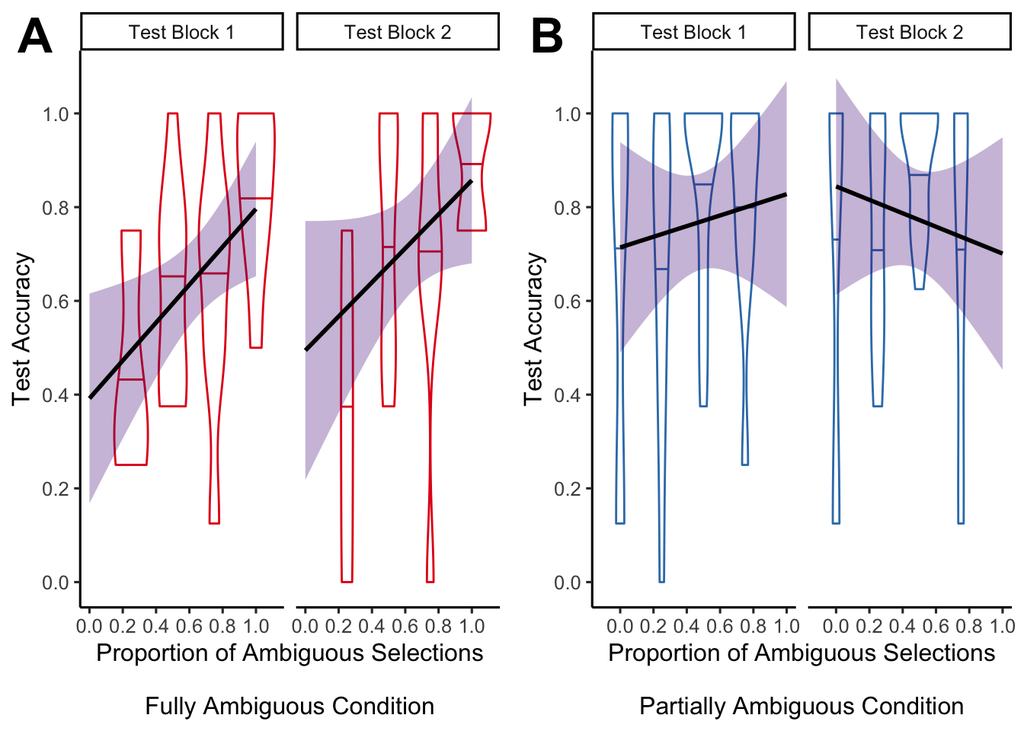

```r
#Experiment S1 - sampling-test
pS1_fullsampling_test <- ggplot(filter(subj_test_half,ambiguity_condition=="ambiguous"),aes(prop_ambig_selection,accuracy, color=ambiguity_condition))+
  geom_violin(aes(group=prop_ambig_selection),draw_quantiles=c(0.5))+
  scale_color_manual(limits=c("ambiguous"),
                     labels=c("fully ambiguous"),
                     values=c("#E41A1C"))+
  #geom_point(position=position_jitter(width=.05,height=.0))+
  geom_smooth(method="lm",color="black",fill="#4B0082",alpha=0.3)+
  theme_classic()+
  #ylim(0,1.08)+
  scale_x_continuous(breaks=c(0,0.2,0.4,0.6,0.8,1))+
  scale_y_continuous(breaks=c(0,0.2,0.4,0.6,0.8,1),limits=c(0,1.08))+
  theme_classic(base_size=12)+
  ylab("Test Accuracy")+
  theme(legend.position="none")+
  xlab("Proportion of Ambiguous Selections\n\nFully Ambiguous Condition")+
  facet_wrap(~testHalf_name)
pS1_partialsampling_test <- ggplot(filter(subj_test_half,ambiguity_condition=="partially ambiguous"),aes(prop_ambig_selection,accuracy, color=ambiguity_condition))+
  geom_violin(aes(group=prop_ambig_selection),draw_quantiles=c(0.5))+
  scale_color_manual(limits=c("partially ambiguous"),
                     labels=c("partially ambiguous"),
                     values=c("#377EB8"))+
  #geom_point(position=position_jitter(width=.05,height=.0))+
  geom_smooth(method="lm",color="black",fill="#4B0082",alpha=0.3)+
  theme_classic()+
  #ylim(0,1.08)+
  scale_x_continuous(breaks=c(0,0.2,0.4,0.6,0.8,1))+
  scale_y_continuous(breaks=c(0,0.2,0.4,0.6,0.8,1),limits=c(0,1.08))+
  theme_classic(base_size=12)+
  ylab("Test Accuracy")+
  theme(legend.position="none")+
  xlab("Proportion of Ambiguous Selections\n\nPartially Ambiguous Condition")+
  facet_wrap(~testHalf_name)
plot_grid(pS1_fullsampling_test,pS1_partialsampling_test,labels=c("A","B"),rel_widths=c(1,1),label_size=24,nrow=1)
```

#### Increase in test accuracy related to sampling preference

By including a test phase immediately preceding the Sampling Phase, we aimed to further understand the correlation between test accuracy and preference for selecting ambiguous items observed in Experiment 1. Specifically, do participants have higher test accuracy at the conclusion of the experiment because they preferentially selected ambiguous items, or do participants who are more successful at learning the object-label associations show a stronger preference for selecting ambiguous items?

To test this question, we correlated participants’ proportion of ambiguous selections with their increase in accuracy from Test Block 1 to Test Block 2. If participants’ ambiguous selections are driving higher accuracy, then participants who show a preference for sampling ambiguous items should show the largest increases in accuracy from Test Block 1 to Test Block 2. However, proportion of ambiguous items selected was not significantly correlated with an increase in test accuracy in the Fully Ambiguous condition and negatively correlated in the Partially Ambiguous condition, i.e. participants who were more likely to select the (partially) ambiguous items showed a lesser increase in test accuracy.

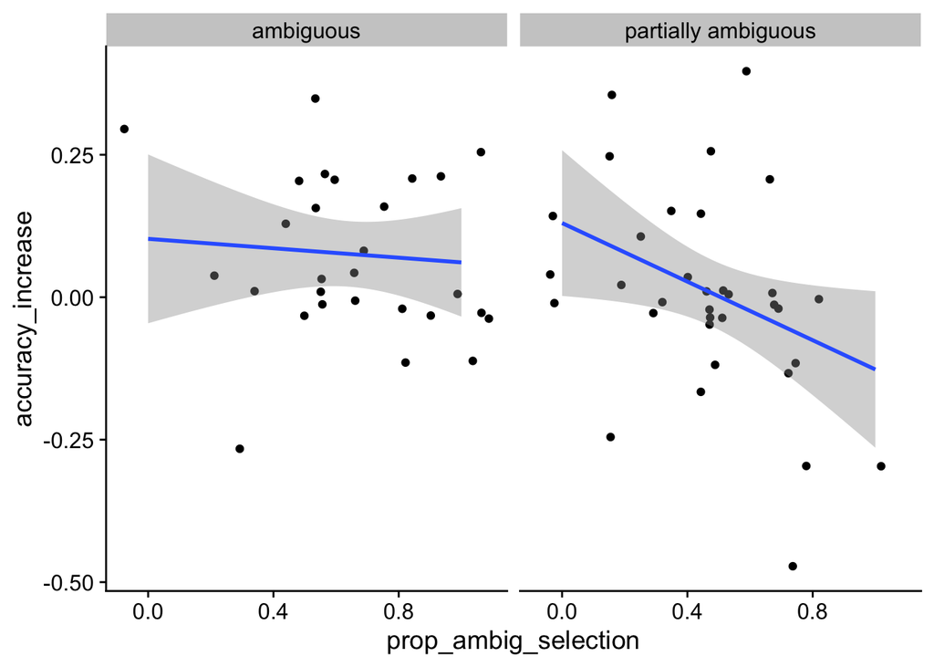

```r
#increase in accuracy block 1 to 2
subj_test_half_wide <- subj_test_half %>%
  select(-testHalf_name) %>%
  pivot_wider(names_from=testHalf,values_from=accuracy,names_prefix="test_block_") %>%
  mutate(accuracy_increase=test_block_2-test_block_1)

ggplot(filter(subj_test_half_wide,experiment_name=="Experiment S1"),aes(prop_ambig_selection,accuracy_increase))+
  geom_jitter()+
  geom_smooth(method="lm")+
  facet_wrap(~ambiguity_condition)
```

##### Fully Ambiguous Condition - Correlation between accuracy increase and sampling preference

```r
#Fully Ambiguous - accuracy increase
cor.test(subset(subj_test_half_wide,ambiguity_condition=="ambiguous"&experiment_name=="Experiment S1")$accuracy_increase,subset(subj_test_half_wide,ambiguity_condition=="ambiguous"&experiment_name=="Experiment S1")$prop_ambig_selection)
```

```
##
##  Pearson's product-moment correlation
##
## data:  subset(subj_test_half_wide, ambiguity_condition == "ambiguous" &  and subset(subj_test_half_wide, ambiguity_condition == "ambiguous" &     experiment_name == "Experiment S1")$accuracy_increase and     experiment_name == "Experiment S1")$prop_ambig_selection
## t = -0.3999, df = 26, p-value = 0.6925
## alternative hypothesis: true correlation is not equal to 0
## 95 percent confidence interval:
##  -0.4384737  0.3037503
## sample estimates:
##         cor
## -0.07818698
```

##### Partially Ambiguous Condition - Correlation between accuracy increase and sampling preference

```r
#Partially Ambiguous - increase
cor.test(subset(subj_test_half_wide,ambiguity_condition=="partially ambiguous"&experiment_name=="Experiment S1")$accuracy_increase,subset(subj_test_half_wide,ambiguity_condition=="partially ambiguous"&experiment_name=="Experiment S1")$prop_ambig_selection)
```

```
##
##  Pearson's product-moment correlation
##
## data:  subset(subj_test_half_wide, ambiguity_condition == "partially ambiguous" &  and subset(subj_test_half_wide, ambiguity_condition == "partially ambiguous" &     experiment_name == "Experiment S1")$accuracy_increase and     experiment_name == "Experiment S1")$prop_ambig_selection
## t = -2.1986, df = 32, p-value = 0.03525
## alternative hypothesis: true correlation is not equal to 0
## 95 percent confidence interval:
##  -0.62398746 -0.02746191
## sample estimates:
##        cor
## -0.3622634
```

##### By Test Item (plot)

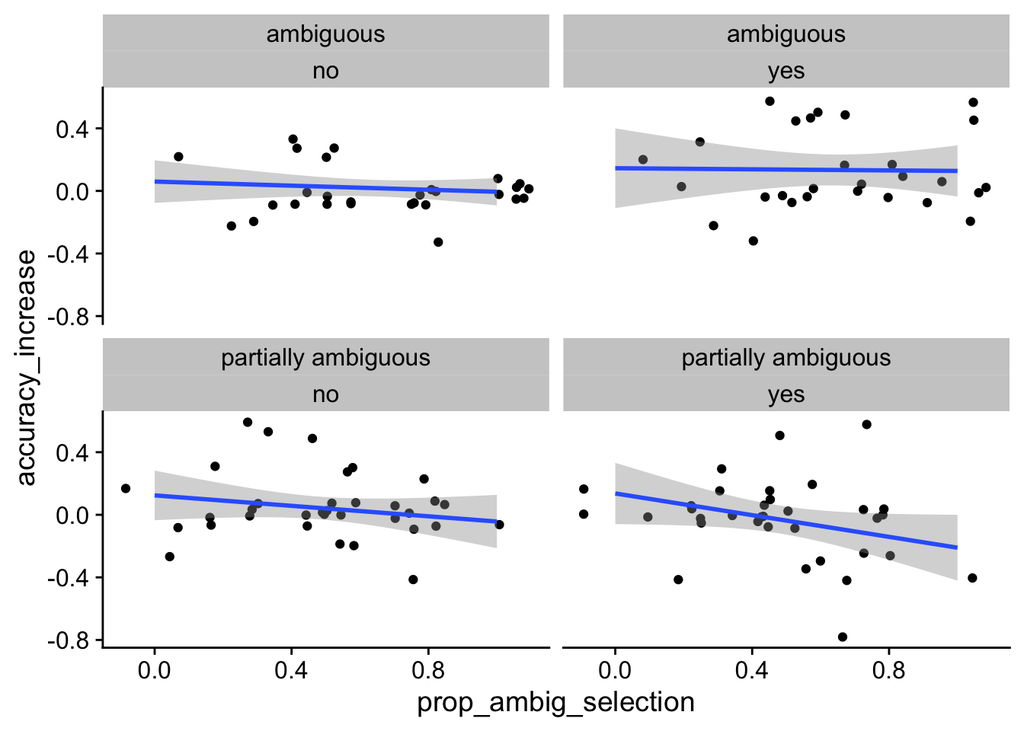

```r
#by item
subj_test_half_item <- subj_test_half_item %>%
  left_join(select(subj_selection,subject,prop_ambig_selection))

subj_test_half_item_wide <- subj_test_half_item %>%
  pivot_wider(names_from=testHalf,values_from=accuracy,names_prefix="test_block_") %>%
  mutate(accuracy_increase=test_block_2-test_block_1)

ggplot(subj_test_half_item_wide,aes(prop_ambig_selection,accuracy_increase))+
  geom_jitter()+
  geom_smooth(method="lm")+
  facet_wrap(~ambiguity_condition+targetIsAmbiguousYN)
```